# RESEARCH PROTOCOL Large-scale evidence generation and evaluation across a network of databases for type 2 diabetes mellitus under heterogeneity

Version: 1.0.0

# 1 List of Abbreviations

| CDM | Common data model |
| --- | --- |
| DPP4 | Dipeptidyl peptidase-4 |
| GLP1 | Glucagon-like peptide-1 |
| IRB | Institutional review board |
| LEGEND | Large-scale Evidence Generation and Evaluation across a Network of Databases |
| MACE | Major adverse cardiovascular event |
| MDRR | Minimum detectable risk ratio |
| OHDSI | Observational Health Data Science and Informatics |
| OMOP | Observational Medical Outcomes Partnership |
| PS | Propensity score |
| RCT | Randomized controlled trial |
| SGLT2 | Sodium-glucose co-transporter-2 |
| T2DM | Type 2 diabetes mellitus |

# 2 Responsible Parties

## 2.1 Investigators

| Investigator | Institution/Affiliation |
| --- | --- |
| George Hripcsak | Department of Biomedical Informatics, Columbia University, New York, NY, USA |
| Rohan Khera | Department of Internal Medicine, Yale University, New Haven, CT, USA |
| Harlan M. Krumholz | Department of Internal Medicine, Yale University, New Haven, CT, USA |
| Yuan Lu | Department of Internal Medicine, Yale University, New Haven, CT, USA |
| Patrick B. Ryan | Observational Health Data Analytics, Janssen Research and Development, Titusville, NJ, USA |
| Martijn J. Schuemie | Observational Health Data Analytics, Janssen Research and Development, Titusville, NJ, USA |
| Marc A. Suchard * | Department of Biostatistics, University of California, Los Angeles, Los Angeles, CA, USA |

* Principal Investigator

## 2.2 Disclosures

This study is undertaken within Observational Health Data Sciences and Informatics (OHDSI), an open collaboration. **RK** is a founder of Evidence2Health, and receives grant funding from the US National Institutes of Health. **MJS** and **PBR** are employees of Janssen Research and Development and shareholders in John & Johnson. **GH** receives grant funding from the US National Institutes of Health and the US Food & Drug Administration and contracts from Janssen Research and Development. **HMK** receives grants from the US Food & Drug Administration, Medtronics and Janssen Research and Development, is co-founder of HugoHealth and chairs the Cardiac Scientific Advisory Board for UnitedHealth. **MAS** receives grant funding from the US National Institutes of Health, the US Department of Veterans Affairs and the US Food & Drug Administration and contracts from Janssen Research and Development and IQVIA.

# 3 Abstract

**Background and Significance**: Type 2 diabetes mellitus (T2DM) is a major cause of morbidity and mortality globally and is associated with an elevated risk of cardiovascular events. Therapeutic options for T2DM have expanded over the last decade with the emergence of sodium-glucose co-transporter-2 (SGLT2) inhibitors and glucagon-like peptide-1 (GLP1) receptor agonists, which reduced the risk of major cardiovascular events in randomized controlled trials (RCTs). Cardiovascular evidence for older second-line agents, such as sulfonylureas, and direct head-to-head comparisons, including with dipeptidyl peptidase 4 (DPP4) inhibitors, are lacking, leaving a critical gap in our understanding of the relative effects of T2DM agents on cardiovascular risk and on patient-centered safety outcomes.

**Study Aims**: To determine real-world comparative effectiveness and safety of traditionally second-line T2DM agents using health information encompassing millions of patients with T2DM, with a focus on individuals at moderate cardiovascular risk and other key subgroups.

**Study Description**: We will conduct three large-scale, systematic, observational studies to make pairwise comparisons of all SGLT2 inhibitor, GLP1 receptor agonist, DPP4 inhibitor and sulfonylurea agents at the drug-, class- and population subgroup-level within our proposed Large-Scale Evidence Generations Across a Network of Databases for T2DM (LEGEND-T2DM) initiative. LEGEND-T2DM will leverage the Observational Health Data Science and Informatics (OHDSI) community that provides access to a standing global network of administrative claims and electronic health record (EHR) data sources. The 13 data sources already committed to LEGEND-T2DM cover $>$ 190 million patients in the US and about 50 million internationally, and include two academic medical centers, IBM MarketScan and Optum databases, and the US Department of Veterans Affairs. LEGEND-T2DM will study:

- **Population**: Adult, T2DM patients who newly initiate a traditionally second-line T2DM agent, including individuals with and without established cardiovascular disease

Preliminary work in our data sources reveals > 1 million such new-users of SGLT2 inhibitors, GLP1 receptor agonists, DPP4 inhibitors or sulfonylureas with no prior, observed use of other second-line agents to best emulate the idealized RCT one would aim to run if it were practical, to compare:

- **Comparators**:
  - SGLT2 inhibitors: canagliflozin, dapagliflozin, empagliflozin, ertugliflozin
  - GLP1 receptor agonists: albiglutide, dulaglutide, exenatide, liraglutide, lixisenatide, semaglutide
  - DPP4 inhibitors: alogliptin, linagliptin, saxagliptin, sitagliptin, vildagliptin
  - Sulfonylureas: chlorpropamide, glimepiride, glipizide, gliquidone, glyburide, tolazamide, tolbutamide

LEGEND-T2DM will execute all pairwise class-vs-class and drug-vs-drug comparisons in each data source that meet a minimum patient count of 1,000 per arm and extensive study diagnostics that assess reliability and generalizability through cohort balance and equipoise to examine the relative risk of cardiovascular and safety outcomes:

- **Outcomes**:
  - Primary: 3- and 4-point major adverse cardiovascular events
  - Secondary effectiveness: Acute myocardial infarction, acute renal failure, glycemic control, hospitalization for heart failure, measured renal dysfunction, stroke, sudden cardiac death
  - Secondary safety: Abnormal weight gain or loss, acute pancreatitis, all-cause mortality, bladder cancer, bone fracture, breast cancer, diabetic ketoacidosis, diarrhea, genitourinary infection, hyperkalemia, hypoglycemia, hypoglycemia, hypotension, joint pain, lower extremity amputation, nausea, peripheral edema, photosensitivity, renal cancer, thyroid tumor, venous thromboembolism, vomiting

For each data source and comparison, LEGEND-T2DM will employ a state-of-the-art design:

- **Design**: Observational: active-comparator, new-user cohort study

and committed LEGEND-T2DM data sources provide:

- **Timeframe**: Up to 6-year (SGLT2 inhibitors) to 20-year (sulfonylureas) follow-up for all outcomes

Our systematic framework will address residual confounding, publication bias and $p$-hacking using data-driven, large-scale propensity adjustment for measured confounding, a large set of negative control outcome experiments to address unmeasured and systematic bias, prespecification and full disclosure of hypotheses tested and their results. These approaches capitalize on mature OHDSI open source resources and a large body of clinical and quantitative research that the LEGEND-T2DM investigators originated and continue to drive. Finally, LEGEND-T2DM is dedicated to open science and transparency and will publicly share all our analytic code from reproducible cohort definitions through turn-key software, enabling other research groups to leverage our methods, data, and results in order to verify and extend our findings.

# 4 Amendments and Updates

| Number | Date | Section of study protocol | Amendment or update | Reason |
| --- | --- | --- | --- | --- |
| 1 | 22-May-2025 | Various | Update | Added heterogeneity study components. |

# 5 Milestones

| Milestone | Planned / actual date |
| --- | --- |
| EU PAS registration | 01-Oct-2021 / 07-Oct-2021 |
| Start of analysis | 01-Nov-2021 |
| End of analysis |  |
| Results presentation |  |

# 6 Rationale and Background

The landscape of therapeutic options for type 2 diabetes mellitus (T2DM) has been dramatically transformed over the last decade [1]. The emergence of drugs targeting the sodium-glucose co-transporter-2 (SGLT2) and the glucagon-like peptide-1 (GLP1) receptor has expanded the role of T2DM agents from lowering blood glucose to directly reducing cardiovascular risk [2]. A series of large randomized clinical trials designed to evaluate the cardiovascular safety of SGLT2 inhibitors and GLP1 receptor agonists found that use of many of these agents led to a reduction in major adverse cardiovascular events, including myocardial infarction, hospitalization for heart failure, and cardiovascular mortality [3–6]. However, other T2DM drugs widely used before the introduction of these novel agents, such as sulfonylureas, did not undergo similarly comprehensive trials to evaluate their cardiovascular efficacy or safety. The effectiveness and safety of these agents can vary by subgroups like age, sex, and race, which limits the assessment that may guide individual patients’ treatment. Being able to tailor treatments to patients may inform clinical practice and improve outcomes. The lack of knowledge of the best context for each agent provides an opportunity for systematic, large-scale observational studies.

# 7 Study Objectives

To inform critical decisions facing patients with diabetes, their caregivers, clinicians, policymakers and healthcare system leaders, we have launched the Large-Scale Evidence Generation and Evaluation across a Network of Databases for Diabetes (LEGEND-T2DM) initiative to execute a series of comprehensive observational studies to compare cardiovascular outcome rates and safety of T2DM glucose-lowering agents. Specifically, these studies aim

1. To determine, through systematic evaluation, the comparative effectiveness and safety of T2DM agents, including biguanides, SGLT2 inhibitors, GLP1 receptor agonists, DPP4 inhibitors, and sulfonylureas among patients with T2DM.
2. To assess heterogeneity in effectiveness and safety of T2DM agents among key patient subgroups: Using stratified patient cohorts, we will quantify differential effectiveness and safety across subgroups of patients based on age, sex, race, renal impairment, and baseline cardiovascular risk.

# 8 Research Methods

LEGEND-T2DM will execute systematic, large-scale observational studies of T2DM agents to estimate the relative risks of cardiovascular effectiveness and safety outcomes.

This **Heterogeneity Study** at the class and individual-drug level for T2DM patients for important subgroups.

In contrast to a single comparison approach, LEGEND-T2DM will provide a comprehensive view of the findings and their consistency across populations, drugs, and outcomes. We will model each study on our successful collaborative research evaluating the comparative effectiveness of antihypertensives recently published in *The Lancet* [7].

For each comparison, we are interested in the relative risk of each of the cardiovascular and safety outcomes described in Section 8.5.

Table 8.1: T2DM drug classes and individual agents within each class

| DPP4 inhibitors | GLP1 receptor antagonists | SGLT2 inhibitors | Sulfonylureas |
| --- | --- | --- | --- |
| alogliptin | albiglutide | canagliflozin | chlorpropamide |
| linagliptin | dulaglutide | dapagliflozin | glimepiride |
| saxagliptin | exenatide | empagliflozin | glipizide |
| sitagliptin | liraglutide | ertugliflozin | gliquidone |
| vildagliptin | lixisenatide |  | glyburide |
|  | semaglutide |  | tolazamide |
|  |  |  | tolbutamide |

In addition to the drugs listed in Table 8.1, we will also consider the sub-group stratifications listed in Table 8.2. We will calculate the relative risk of each of the cardiovascular and safety outcomes described in Section 8.5, but additionally stratify the relative risks of the outcomes using the subgroups described below.

Table 8.2: Subgroup definitions used for stratified analysis

| Subgroup Name | Brief Description |
| --- | --- |
| Age | 3 age groups, <21, 21-60, >60 |
| Sex | Male vs. Female |
| Race | Black vs. White |
| Renal disease | 3 groups for renal disease, (1) none, (2) Chronic kidney disease, not on dialysis, (3) Chronic kidney disease, on dialysis |
| Obesity | Obesity is defined as a BMI measurement >30 (WHO definition), or body weight >120kg, or a condition occurance of an obesity diagnosis |
| Diabetes severe | Severe diabetes is defined as individuals with an HbA1c >8, or condition code occurance of “Type II diabetes mellitus uncontrolled” or “Diabetic - poor control” |
| Diabetetic Ketoacidosis | Defined as having a condition occurance of diabetic ketoacidosis |
| Diabetic Retinopathy | Defined as having a condition occurance of diabetic retinopathy |
| Essential Hypertension | Defined as having a condition occurance of hypertension |
| Hyperlipidemia | Defined as having a condition occurance of hyperlipedemia |
| Metabolic dysfunction-associated steatotic liver disease (MASLD) | Defined as having a condition occurance of non-alcoholic steatohepatitis or non-alcoholic fatty liver disease without non-alcoholic steatohepatitis |

## 8.1 Study Design

For each study, we will employ an active comparator, new-user cohort design [8–10]. New-user cohort design is advocated as the primary design to be considered for comparative effectiveness and drug safety [11–13]. By identifying patients who start a new treatment course and using therapy initiation as the start of follow-up, the new-user design models an randomized controlled trial (RCT) where treatment commences at the index study visit. Exploiting such an index date allows a clear separation of baseline patient characteristics that occur prior to index date and are usable as covariates in the analysis without concern of inadvertently introducing mediator variables that arise between exposure and outcome [14]. Excluding prevalent users as those without a sufficient washout period prior to first exposure occurrence further reduces bias due to balancing mediators on the causal pathway, time-varying hazards, and depletion of susceptibles [13,15]. Our systematic framework across studies further will address residual confounding, publication bias, and p-hacking using data-driven, large-scale propensity adjustment for measured confounding [16], a large set of negative control outcome experiments to address unmeasured and systematic bias [17–19], and full disclosure of hypotheses tested [20]. Figure 8.1 illustrates our design for all studies that the following sections describe in more detail.

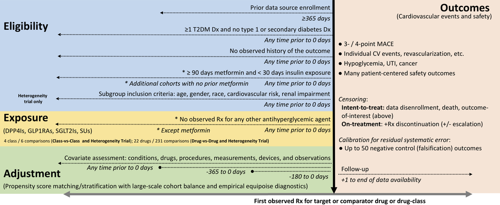

Figure 8.1: Schematic of LEGEND-T2DM new-user cohort design for the Class-vs-Class, Drug-vs-Drug and Heterogeneity studies.

## 8.2 Data Sources

We will execute LEGEND-T2DM as a series of OHDSI network studies. All data partners within OHDSI are encouraged to participate voluntarily and can do so conveniently, because of the community’s shared Observational Medical Outcomes Partnership (OMOP) common data model (CDM) and OHDSI tool-stack. Many OHDSI community data partners have already committed to participate and we will recruit further data partners through OHDSI’s standard recruitment process, which includes protocol publication on OHDSI’s GitHub, an announcement in OHDSI’s research forum, presentation at the weekly OHDSI all-hands-on meeting and direct requests to data holders.

Table 8.3 lists potential data sources for LEGEND-T2DM; these sources encompass a large variety of practice types and populations. For each data source, we report a brief description and size of the population it represents and its patient capture process and start date. While the earliest patient capture begins in 1989 (CUIMC), the vast majority come from the mid-2000s to today, providing almost two decades of T2DM treatment coverage. US populations include those commercially and publicly insured, enriched for older individuals (MDCR, VA), lower socioeconomic status (MDCD), and racially diverse (VA >20% Black or African American, CUIMC 8%). The US data sources may capture the same patients across multiple sources. Different views of the same patients are an advantage in capturing the diversity of real-world health events that patients experience. Across CCAE (commercially insured), MCDR (Medicare) and MCDC (Medicaid), we expect little overlap in terms of the same observations recorded at the same time for a patient; patients can flow between sources (e.g., a CCAE patient who retires can opt-in to become an MDCR patient), but the enrollment time periods stand distinct. On the other hand, Optum, PanTher, OpenClaims, CUIMC and YNHHS may overlap in time with the other US data sources. While it remains against licensing agreements to attempt to link patients between most data sources, Optum reports <20% overlap between their claims and EHR data sources that is reassuringly small. All data sources will receive institutional review board approval or exemption for their participation before executing LEGEND-T2DM.

Table 8.3: Committed LEGEND-T2DM data sources and the populations they cover.

| Data source | Population | Patients | History | Data capture process and short description |
| --- | --- | --- | --- | --- |
| **Administrative claims** |  |  |  |  |
| IBM MarketScan Commercial Claims and Encounters (CCAE) | Commercially insured, < 65 years | 142M | 2000 – | Adjudicated health insurance claims (e.g. inpatient, outpatient, and outpatient pharmacy) from large employers and health plans who provide private healthcare coverage to employees, their spouses and … |
| IBM MarketScan Medicare Supplemental Database (MDCR) | Commercially insured, 65$+$ years | 10M | 2000 – | Adjudicated health insurance claims of retirees with primary or Medicare supplemental coverage through privately insured fee-for-service, point-of-service or capitated health plans. |
| IBM MarketScan Multi-State Medicaid Database (MDCD) | Medicaid enrollees, racially diverse | 26M | 2006 – | Adjudicated health insurance claims for Medicaid enrollees from multiple states and includes hospital discharge diagnoses, outpatient diagnoses and procedures, and outpatient pharmacy claims. |
| IQVIA Open Claims (IOC) | General | 160M | 2010 – | Pre-adjudicated claims at the anonymized patient-level collected from office-based physicians and specialists via office management software and clearinghouse switch sources for the purpose of reimbur… |
| Japan Medical Data Center (JMDC) | Japan, general | 5.5M | 2005 – | Data from 60 society-managed health insurance plans covering workers aged 18 to 65 and their dependents. |
| Korea National Health Insurance Service (NHIS) | 2% random sample of South Korea | 1M | 2002 – | National administrative claims database covering the South Korean population. |
| Optum Clinformatics Data Mart (Optum) | Commercially or Medicare insured | 85M | 2000 – | Inpatient and outpatient healthcare insurance claims. |
| **Electronic health records (EHRs)** |  |  |  |  |
| Columbia University Irving Medical Center (CIUMC) | Academic medical center patients, racially diverse | 6M | 1989 – | General practice, specialists and inpatient hospital services from the New York-Presbyterian hospital and affiliated academic physician practices in New York. |
| Department of Veterans Affairs (VA) | Veterans, older, racially diverse | 12M | 2000 – | National VA health care system, the largest integrated provider of medical services in the US, provided at 170 VA medical centers and 1,063 outpatient sites. |
| Information System for Research in Primary Care (SIDIAP) | 80% of all Catalonia (Spain) | 7.7M | 2006 – | Primary care partially linked to inpatient data with pharmacy dispensations and primary care laboratories. Healthcare is universal and taxpayer funded in the region, and PCPs are gatekeeps for all car… |
| IQVIA Disease Analyzer Germany (DAG) | Germany, general | 37M | 1992 – | Collection from patient management software used by general practitioners and selected specialists to document patients’ medical records within their office-based practice during a visit. |
| Optum Electronic Health Records (OptumEHR) | US, general | 93M | 2006 – | Clinical information, prescriptions, lab results, vital signs, body measurements, diagnoses and procedures derived from clinical notes using natural language processing. |
| Yale New Haven Health System (YNHHS) | Academic medical center patients | 2M | 2013 – | General practice, specialists and inpatient hospital services from the YNHHS in Connecticut. |

## 8.3 Study Population

We will include all subjects in a data source who meet inclusion criteria for T2DM agent exposure cohorts. Broadly, these cohorts will consist of T2DM patients who initiate treatment with one of the drug ingredients that comprise the biguanide, DPP4 inhibitor, GLP1 receptor agonist, SGT2 inhibitor and sulfonylurea drug classes (Table 8.1). We do not consider thiazolidinediones given their known association with a risk of heart failure and bladder cancer [21,22]. We describe specific definitions for exposure cohorts for each study in the following sections.

## 8.4 Exposure Comparators

### 8.4.1 Class-vs-Class Study comparisons

The **Class-vs-Class** Study will construct exposure cohorts for new-users of any drug ingredient within the drug classes in Table 8.1. Cohort entry (index date) for each patient is their first observed exposure to any drug ingredient for the drug classes. Consistent with an idealized target trial for T2DM therapy and cardiovascular risk [23,24], inclusion criteria for patients based on the index date will include:

- T2DM diagnosis and no Type 1 or secondary diabetes mellitus diagnosis before the index date;
- At least 1 year of observation time before the index date (to improve new-user sensitivity); and
- No prior drug exposure to a comparator or other antihyperglycemic agent (i.e. thiazolidinediones, acarbose, acetohexamide, bromocriptine, glibornuride, miglitol and nateglinide) or $>$ 30 days insulin exposure before index date.

We purposefully do not automatically exclude or restrict to patients with a history of myocardial infarction, stroke or other major cardiovascular events, which will allow us to report relative effectiveness and safety for individuals with both low or moderate and high cardiovascular risk. Likewise, we do not automatically exclude or restrict to individuals with severe renal impairment [25]. We will use cohort diagnostics, such as achieving covariate balance and clinical empirical equipoise between exposure cohorts (Section 9) and stakeholder input to guide the possible need to exclude other prior diagnoses, such as congestive heart failure, pancreatitis or cancer [25].

Appendix A.1 reports the complete OHDSI `ATLAS` cohort description for new-users of DDP4 inhibitors. This description lists complete specification of cohort entry events, additional inclusion criteria, cohort exit events, and all associated standard OMOP CDM concept code sets used in the definition. We generate programmatically equivalent cohort definitions for new-others of each drug class with and without prior metformin use. `ATLAS` then automatically translates these definitions into network-deployable SQL source code.

Of note, the inclusion criteria do not directly incorporate quantitative measures of poor glycemic control, such as one or more elevated serum HbA1c measurements; such laboratory values are irregularly captured in large claims and even EHR data sources.

For each data source, we will then execute all pairwise class comparisons for which the data source yields $\ge$ 1,000 patients in each arm. Significantly fewer numbers of patients strongly suggest data source-specific differences in prescribing practices that may introduce residual bias and sufficient samples sizes are required to construct effective propensity score models [7].

### 8.4.2 Drug-vs-Drug Study comparisons

The **Drug-vs-Drug Study** (if powered) will construct exposure cohorts for new-users of each drug ingredient in Table 8.1. We will apply the same cohort definition, inclusion criteria and patient count minimum as described in Section 8.4.1.

For each data source, we will then execute all pairwise drug comparisons. While we will publicly report studies results for all pairwise comparisons, we will focus primary clinical interpretation and scientific publishing to the comparisons that pit drugs within the same class against each other, as well as across-class comparisons that stakeholders deem pertinent given their experiences.

### 8.4.3 Heterogeneity Study comparisons

The **Heterogeneity Study** will stratify all class- and drug-level exposure cohorts in Sections 8.4.1 and 8.4.2 by clinically important patient characteristics that modify cardiovascular risk or relative treatment heterogeneity to provide patient-focused treatment recommendations. These factors will include:

- Age (<21, 21 - 60, >60 at the index date)
- Biological Sex (female / male)
- Race (African American or black)
- Renal impairment (at the index date) as unimpaired, impaired without dialysis, on-dialysis
- Obesity
- Diabetes severity
- Diabetic Ketoacidosis
- Diabetic Retinopathy
- Essential Hypertension
- Hyperlipidemia
- Metabolic dysfunction-associated steatotic liver disease (MASLD)

We will define patients with renal impairment through diagnosis codes for chronic kidney disease and end-stage renal disease, dialysis procedures, and laboratory measurements of estimated glomerular filtration rate, serum creatinine and urine albumin. Obesity will be defined using the WHO definition (BMI >30), body weight >120 kg (or equivalent in pounds), or a diagnosis code for obesity. Poorly controlled diabetes will be defined an HbA1c >8, or a diagnosis code for uncontrolled type 2 diabetes or poor diabetes control. Diabetic ketoacidosis, Diabetic Retinopathy, Essential Hypertension, Hyperlipidemia, and MASLD will be defined based on the presence of relevant diagnosis codes in the patient’s medical history.

Appendix A.4 presents complete OHDSI `ATLAS` specifications for these subgroups, including all standard OMOP CDM concept codes defining cardiovascular risk and renal disease.

### 8.4.4 Validation

We will validate exposure cohorts and aggregate drug utilization using comprehensive cohort characterization tools against both claims and EHR data sources. Chief among these tools stands OHDSI’s `CohortDiagnostic` package ([github](https://ohdsi.github.io/CohortDiagnostics/)). For any cohort and data source mapped to OMOP CDM, this package systematically generates incidence new-user rates (stratified by age, gender, and calendar year), cohort characteristics (all comorbidities, drug use, procedures, health utilization) and the actual codes found in the data triggering the various rules in the cohort definitions. This can allow researchers and stakeholders to understand the heterogeneity of source coding for exposures and health outcomes as well as the impact of various inclusion criteria on overall cohort counts (details described in Section 9).

## 8.5 Outcomes

Across all data sources and pairwise exposure cohorts, we will assess relative risks of 11 cardiovascular and patient-centered outcomes (Table 8.4).

Cardiovascular outcomes include: * Acute myocardial infarction, * acute renal failure, * hospitalization with heart failure, and * stroke

Patient-centered safety outcomes include: * Acute pancreatitis, * diabetic ketoacidosis, * diarrhea, * vomiting, and * hepatic failure

We will also study T2DM drug side-effects and safety concerns highlighted in the 2018 ADA guidelines [27] and from RCTs, including:

- abnormal weight change and
- hypoglycemia.

We will employ the same level of systematic rigor in studying outcomes regardless of their primary or secondary label.

A majority of outcome definitions have been previously implemented and validated in our own work [7,28–32] based heavily on prior development by others (see references in Table 8.4 [29–31,33–71]). To assess across-source consistency and general clinical validity, we will characterize outcome incidence, stratified by age, sex and index year for each data source.

Table 8.4: LEGEND-T2DM study outcomes

| Phenotype | Brief logical description | Prior development |
| --- | --- | --- |
| **Cardiovascular outcomes** |  |  |
| Acute myocardial infarction | Condition record of acute myocardial infarction during an inpatient or ER vist | [33–38] |
| Acute renal failure | Condition record of acute renal failure during an inpatient or ER visit | [31,39–46] |
| Hospitalization with heart failure | Inpatient or ER visit with heart failure condition record | [29,47–52] |
| Stroke | Condition record of hemorrhagic or ischemic stroke during an inpatient or ER visit | [53–58] |
| Abnormal weight gain | Abnormal weight gain record of any type; successive records with > 90 day gap are considered independent episodes; note, weight measurements not used | [59] |
| Acute pancreatitis | Condition record of acute pancreatitis during an inpatient or ER visit | [60–63] |
| Diabetic ketoacidosis | Diabetic ketoacidosis condition record during an inpatient or ER visit | [30,64] |
| Diarrhea | Diarrhea condition record of any type; successive records with > 30 day gap are considered independent episodes | [65–67] |
| Hypoglycemia | Hypoglycemia condition record of any type; successive records with > 90 day gap are considered independent episodes | [68] |
| Vomiting | Vomiting condition record of any type; successive records with > 30 day gap are considered independent episodes | [69–71] |
| **Patient-centered safety outcomes** |  |  |
| Hepatic failure | The first condition record of hepatic failure |  |

## 8.6 Analysis

### 8.6.1 Contemporary utilization of drug classes and individual agents

For all cohorts in the three studies, we will describe overall utilization as well as temporal trends in the use of each drug class and agents within the class. Further, we will evaluate these trends in patient groups by age (18-44 / 45-64 / $\ge$ 65 years), gender, race and geographic regions. Since the emergence of novel medications in the management of type 2 DM in 2014, there has been a rapid expansion in both the number of drug classes and individual agents. These data will provide insight into the current patterns of use and possible disparities. These data are critical to guide the real-world application of treatment decision pathways for the treatment of T2DM patients.

Specifically, we will calculate and validate aggregate drug utilization using the OHDSI’s CohortDiagnostic package against both claims and EHR data sources. The CohortDiagnostics package works in two steps: 1) Generate the utilization results and diagnostics against a data source and 2) Explore the generated utilization and diagnostics in a user-friendly graphical interface R-Shiny app. Through the interface, one can explore patient profiles of a random sample of subjects in a cohort. These diagnostics provide a consistent methodology to evaluate cohort definitions/phenotype algorithms across a variety of observational databases. This will enable researchers and stakeholders to become informed on the appropriateness of including specific data sources within analyses, exposing potential risks related to heterogeneity and variability in patient care delivery that, when not addressed in the design, could result in errors such as highly correlated covariates in propensity score matching of a target and a comparator cohort. Thus, the added value of this approach is two-fold in terms of exposing data quality for a study question and ensuring face validity checks are performed on proposed covariates to be used for balancing propensity scores.

### 8.6.2 Relative risk of cardiovascular and patient-centered outcomes

For all three studies, we will execute a systematic process to estimate the relative risk of cardiovascular and patient-centered outcomes between new-users of second-line T2DM agents. The process will adjust for measured confounding, control from further residual (unmeasured) bias and accommodate important design choices to best emulate the nearly impossible to execute, idealized RCT that our stakeholders envision across data source populations, comparators, outcomes and subgroups.

To adjust for potential measured confounding and improve the balance between cohorts, we will build large-scale propensity score (PS) models [72] for each pairwise comparison and data source using a consistent data-driven process through regularized regression [16]. This process engineers a large set of predefined baseline patient characteristics, including age, gender, race, index month/year and other demographics and prior conditions, drug exposures, procedures, laboratory measurements and health service utilization behaviors, to provide the most accurate prediction of treatment and balance patient cohorts across many characteristics. Construction of condition, drug, procedures and observations include occurrences within 365, 180 and 30 days prior to index date and are aggregated at several SNOMED (conditions) and ingredient/ATC class (drugs) levels. Other demographic measures include comorbidity risk scores (Charlson, DCSI, CHADS2, CHAD2VASc). From prior work, feature counts have ranged in the 1,000s - 10,000s, and these large-scale PS models have outperformed hdPS [73] in simulation and real-world examples [16]. Given the subcutaneous route of administration of GLP1RAs compared with other drugs administered orally, device codes that represent needles and associated health management encounters, will be excluded from propensity score construction.

We will:

- Exclude patients who have experienced the outcome prior to their index date,
- Stratify and 1-to-1 match patients by PS, and
- Use Cox proportional hazards models

to estimate hazard ratios (HRs) between alternative target and comparator treatments for the risk of each outcome in each data source. In addition, we will perform a sensitivity analysis that does not exclude individuals who previously experienced a glycemic control outcome before the index date. The regression will condition on the PS strata/matching-unit with treatment allocation as the sole explanatory variable and censor patients at the end of their time-at-risk (TAR) or data source observation period. We will prefer stratification over matching if both sufficiently balance patients (see Section 9), as the former optimizes patient inclusions and thus generalizability.

We will execute each comparison using three different TAR definitions, reflecting different and important causal contrasts:

- Intent-to-treat (TAR: index + 1 → end of observation) captures both direct treatment effects and (long-term) behavioral/treatment changes that initial assignment triggers [74];
- On-treatment-1 (TAR: index + 1 → treatment discontinuation) is more patient-centered [75] and captures direct treatment effect while allowing for escalation with additional T2DM agents; and
- On-treatment-2 (TAR: index + 1 → discontinuation or escalation with T2DM agents) carries the least possible confounding with other concurrent T2DM agents.

Our “on-treatment” is often called “per-protocol” [76]. Systematically executing with multiple causal contrasts enables us to identify potential biases that missing prescription data, treatment escalation and behavioral changes introduce, while preserving the ease of intent-to-treat interpretation and power if the data demonstrate them as unbiased. Appendix A.3 reports the modified cohort exit rule for the on-treatment-2 TAR.

We will aggregate HR estimates across non-overlapping data sources to produce meta-analytic estimates using a random-effects meta-analysis [77]. This classic meta-analysis assumes that per-data source likelihoods are approximately normally distributed [78]. This assumption fails when outcomes are rare as we expect for some safety events. Here, our recent research shows that as the number of data sources increases, the non-normality effect increases to where coverage of 95% confidence intervals (CIs) can be as low as 5%. To counter this, we will also apply a Bayesian meta-analysis model [79,80] that neither assumes normality nor requires patient-level data sharing by building on composite likelihood methods [81] and enables us to introduce appropriate overlap weights between data sources.

### 8.6.3 Subgroup effects

We will calculate subgroup effects in two ways. First, we will calculate the difference in the hazard ratios of different subgroups for each outcome for pairs of classes (or drugs), and we will calculate the statistical significance of that difference. Second, for the 1-to-1 matching comparisons, we will more directly compare incidence rates between subgroups for each outcome for pairs of classes (or drugs). This latter comparison may have more power than comparing hazard ratios.

# 9 Sample Size and Study Power

Within each data source, we will execute all comparisons with $\ge$ 1,000 eligible patients per arm. Blinded to effect estimates, investigators and stakeholders will evaluate extensive study diagnostics for each comparison to assess reliability and generalizability, and only report risk estimates that pass [10,20]. These diagnostics will include

1. Minimum detectable risk ratio (MDRR) as a typical proxy for power,
2. Preference score distributions to evaluate empirical equipoise10 and population generalizability,
3. Extensive patient characteristics to evaluate cohort balance before and after PS-adjustment,
4. Negative control calibration plots to assess residual bias, and
5. Kaplan-Meier plots to examine hazard ratio proportionality assumptions.

We will define cohorts to stand in empirical equipoise if the majority of patients carry preference scores between 0.3 and 0.7 and to achieve balance if all after-adjustment characteristics return absolute standardized mean differences $<$ 0.1 [83].

# 10 Strengths and Limitations

## 10.1 Strengths

LEGEND-T2DM further advances the statistically rigorous and empirically validated methods we have developed in OHDSI that specifically address bias inherent in observational studies and allow for reliable causal inference. Patient characteristics and their treatment choices are likely to confound comparative effectiveness and safety estimates. Our approach combines active comparator new-user designs that emulate randomized clinical trials with large-scale propensity adjustment for measured confounding, a large set of negative control outcome experiments to address unmeasured and systematic bias, and full disclosure of hypotheses tested.

Each LEGEND-T2DM aim will represent evidence synthesis from a large number of bespoke studies across multiple data sources. Addressing questions one bespoke study at a time is prone to errors arising from multiple testing, random variation in effect estimates and publication bias. LEGEND-T2DM is designed to avoid these concerns through methodologic best practices [84] with full study diagnostics and external replication.

Through open science, LEGEND-T2DM will allow any interested investigators to engage as partners in our work at many levels. We will publicly develop all protocols and analytic code. This invites additional data custodians to participate in LEGEND-T2DM and enables others to modify and reuse our approach for other investigations. We will also host real-time access to all study result artifacts for outside analysis and interpretation. Such an open science framework ensures a feed-forward effect on other scientific contributions in the community. Collectively, LEGEND-T2DM will generate patient-centered, high quality, generalizable evidence that will transform the clinical management of T2DM through our active collaboration with patients, clinicians, and national medical societies. LEGEND-T2DM will spur scientific innovation through the generation of open-source resources in data science.

## 10.2 Limitations

Even though many potential confounders will be included in these studies, there may be residual bias due to unmeasured or misspecified confounders, such as confounding by indication, differences in physician characteristics that may be associated with drug choice, concomitant use of other drugs started after the index date, and informative censoring at the end of the on-treatment periods. To minimize this risk, we will use methods to detect residual bias through a large number of negative and positive controls.

Ideal negative controls carry identical confounding between exposures and the outcome of interest [85]. The true confounding structure, however, is unknowable. Instead of attempting to find the elusive perfect negative control, we will rely on a large sample of controls that represent a wide range of confounding structures. If a study comparison proves to be unbiased for all negative controls, we can feel confident that it will also be unbiased for the outcome of interest. In our previous studies [7,10,86], using the active comparator, new-user cohort design we will employ here, we have observed minimal residual bias using negative controls. This stands in stark contrast to other designs such as the (nested) case-control that tends to show large residual bias because of incomparable exposure cohorts implied by the design [87].

Observed follow-up times are limited and variable, potentially reducing power to detect differences in effectiveness and safety and, further, misclassification of study variables is unavoidable in secondary use of health data, so it is possible to misclassify treatments, covariates, and outcomes. Based on our previous successful studies on antihypertensives, we do not expect differential misclassification, and therefore bias will most likely be towards the null. Finally, the electronic health record databases may be missing care episodes for patients due to care outside the respective health systems. Such bias, however, will also most likely be towards the null.

# 11 Protection of Human Subjects

LEGEND-T2DM does not involve human subjects research. The project does, however, use human data collected during routine healthcare provision. Most often the data are de-identified within data source. All data partners executing the LEGEND-T2DM studies within their data sources will have received institutional review board (IRB) approval or waiver for participation in accordance to their institutional governance prior to execution (see Table 11.1). LEGEND-T2DM executes across a federated and distributed data network, where analysis code is sent to participating data partners and only aggregate summary statistics are returned, with no sharing of patient-level data between organizations.

Table 11.1: IRB approval or waiver statement from partners.

| Data source | Statement |
| --- | --- |
| IBM MarketScan Commercial Claims and Encounters (CCAE) | New England Institutional Review Board and was determined to be exempt from broad IRB approval, as this research project did not involve human subject research. |
| IBM MarketScan Medicare Supplemental Database (MDCR) | New England Institutional Review Board and was determined to be exempt from broad IRB approval, as this research project did not involve human subject research. |
| IBM MarketScan Multi-State Medicaid Database (MDCD) | New England Institutional Review Board and was determined to be exempt from broad IRB approval, as this research project did not involve human subject research. |
| IQVIA Open Claims (IOC) | This is a retrospective database study on de-identified data and is deemed not human subject research. Approval is provided for OHDSI network studies. |
| Japan Medical Data Center (JMDC) | New England Institutional Review Board and was determined to be exempt from broad IRB approval, as this research project did not involve human subject research. |
| Korea National Health Insurance Service (NHIS) | Ajou University Institutional Review Board (AJIRB-MED-EXP-17-054 for LEGEND-HTN) and approval expected shortly for LEGEND-T2DM. |
| Optum Clinformatics Data Mart (Optum) | New England Institutional Review Board and was determined to be exempt from broad IRB approval, as this research project did not involve human subject research. |
| Columbia University Irving Medical Center (CIUMC) | Use of the CUIMC data source was approved by the Columbia University Institutional Review Board as an OHDSI network study (IRB# AAAO7805). |
| Department of Veterans Affairs (VA) | Use of the VA-OMOP data source was reviewed by the Department of Veterans Affairs Central Institutional Review Board (IRB) and was determined to meet the criteria for exemption under Exemption Categor… |
| Information System for Research in Primary Care (SIDIAP) | Use of the SIDIAP data source was approved by the Clinical Research Ethics Committee of IDIAPJGol (project code: 20/070-PCV) |
| IQVIA Disease Analyzer Germany (DAG) | This is a retrospective database study on de-identified data and is deemed not human subject research. Approval is provided for OHDSI network studies. |
| Optum Electronic Health Records (OptumEHR) | New England Institutional Review Board and was determined to be exempt from broad IRB approval, as this research project did not involve human subject research. |
| Yale New Haven Health System (YNHHS) | Use of the YNHHS EHR data source was approved by the Yale University Institutional Review Board as an OHDSI network study (IRB# pending). |

# 12 Management and Reporting of Adverse Events and Adverse Reactions

LEGEND-T2DM uses coded data that already exist in electronic databases. In these types of databases, it is not usually possible to link (i.e., identify a potential causal association between) a particular product and medical event for any specific individual. Thus, the minimum criteria for reporting an adverse event (i.e., identifiable patient, identifiable reporter, a suspect product and event) are not available and adverse events are not reportable as individual adverse event reports. The study results will be assessed for medically important findings.

# 13 Plans for Disseminating and Communicating Study Results

Open science aims to make scientific research, including its data process and software, and its dissemination, through publication and presentation, accessible to all levels of an inquiring society, amateur or professional [88] and is a governing principle of LEGEND-T2DM. Open science delivers reproducible, transparent and reliable evidence. All aspects (except private patient data) will be open and we will actively encourage other interested researchers, clinicians and patients to participate. This differs fundamentally from traditional studies that rarely open their analytic tools or share all result artifacts, and inform the community about hard-to-verify conclusions at completion.

## 13.1 Transparent and re-usable research tools

We will publicly register this protocol and announce its availability for feedback from stakeholders, the OHDSI community and within clinical professional societies. This protocol will link to open source code for all steps to generating diagnostics, effect estimates, figures and tables. Such transparency is possible because we will construct our studies on top of the OHDSI toolstack of open source software tools that are community developed and rigorously tested [10].

## 13.2 Continuous sharing of results

LEGEND-T2DM embodies a new approach to generating evidence from healthcare data that overcome weaknesses in the current process of answering and publishing (or not) one question at a time. Generating evidence for thousands of research and control questions using a systematic process enables us to not only evaluate that process and the coherence and consistency of the evidence, but also to avoid $p$-hacking and publication bias [20]. We will store and openly communicate all of these results as they become available using a user-friendly web-based app that serves up all descriptive statistics, study diagnostics and effect estimates for each cohort comparison and outcome. Open access to this app will be through a general public facing LEGEND-T2DM webpage.

## 13.3 Scientific meetings and publications

We will deliver multiple presentations annually at scientific venues including the annual meetings of the American Diabetes Association, American College of Cardiology, American Heart Association and American Medical Informatics Association. We will also prepare multiple scientific publications for clinical, informatics and statistical journals.

## 13.4 General public

We believe in sharing our findings that will guide clinical care with the general public. LEGEND-T2DM will use social-media (Twitter) to facilitate this. With dedicated support from the OHDSI communications specialist, we will deliver regular press releases at key project stages, distributed via the extensive media networks of UCLA, Columbia and Yale.

# References

1

Lo C, Toyama T, Wang Y, *et al.* Insulin and glucose-lowering agents for treating people with diabetes and chronic kidney disease. *Cochrane Database of Systematic Reviews* 2018.

2

North EJ, Newman JD. Review of cardiovascular outcomes trials of sodium-glucose cotransporter-2 inhibitors and glucagon-like peptide-1 receptor agonists. *Current Opinion in Cardiology* 2019;**34**:687–92.

3

Zinman B, Wanner C, Lachin JM, *et al.* Empagliflozin, cardiovascular outcomes, and mortality in type 2 diabetes. *The New England Journal of Medicine* 2015;**373**:2117–28.

4

Neal B, Perkovic V, Mahaffey KW, *et al.* Canagliflozin and cardiovascular and renal events in type 2 diabetes. *The New England Journal of Medicine* 2017;**377**:644–57.

5

Marso SP, Daniels GH, Brown-Frandsen K, *et al.* Liraglutide and cardiovascular outcomes in type 2 diabetes. *The New England Journal of Medicine* 2016;**375**:311–22.

6

Marso SP, Bain SC, Consoli A, *et al.* Semaglutide and cardiovascular outcomes in patients with type 2 diabetes. *The New England Journal of Medicine* 2016;**375**:1834–44.

7

Suchard MA, Schuemie MJ, Krumholz HM, *et al.* Comprehensive comparative effectiveness and safety of first-line antihypertensive drug classes: A systematic, multinational, large-scale analysis. *The Lancet* 2019;**394**:1816–26.

8

Yoshida K, Solomon DH, Kim SC. Active-comparator design and new-user design in observational studies. *Nature Reviews Rheumatology* 2015;**11**:437–41.

9

Ryan PB, Schuemie MJ, Gruber S, *et al.* Empirical performance of a new user cohort method: Lessons for developing a risk identification and analysis system. *Drug Safety: An International Journal of Medical Toxicology and Drug Experience* 2013;**36 Suppl 1**:S59–72.

10

Schuemie MJ, Cepeda MS, Suchard MA, *et al.* How confident are we about observational findings in health care: A benchmark study. *Harvard Data Science Review* 2020;**2**.

11

Schneeweiss S. A basic study design for expedited safety signal evaluation based on electronic healthcare data. *Pharmacoepidemiology and Drug Safety* 2010;**19**:858–68.

12

Gagne JJ, Fireman B, Ryan PB, *et al.* Design considerations in an active medical product safety monitoring system. *Pharmacoepidemiology and Drug Safety* 2012;**21 Suppl 1**:32–40.

13

Johnson ES, Bartman BA, Briesacher BA, *et al.* The incident user design in comparative effectiveness research. *Pharmacoepidemiology and Drug Safety* 2013;**22**:1–6.

14

Schneeweiss S, Patrick AR, Stürmer T, *et al.* Increasing levels of restriction in pharmacoepidemiologic database studies of elderly and comparison with randomized trial results. *Medical Care* 2007;**45**:S131–42.

15

Suissa S, Moodie EEM, Dell’Aniello S. Prevalent new-user cohort designs for comparative drug effect studies by time-conditional propensity scores. Pharmacoepidemiology and Drug Safety. 2017;**26**:459–68.

16

Tian Y, Schuemie MJ, Suchard MA. Evaluating large-scale propensity score performance through real-world and synthetic data experiments. *International Journal of Epidemiology* 2018;**47**:2005–14.

17

Schuemie MJ, Ryan PB, DuMouchel W, *et al.* Interpreting observational studies: Why empirical calibration is needed to correct p-values. *Statistics in Medicine* 2014;**33**:209–18.

18

Schuemie MJ, Hripcsak G, Ryan PB, *et al.* Robust empirical calibration of p -values using observational data. Statistics in Medicine. 2016;**35**:3883–8.

19

Schuemie MJ, Hripcsak G, Ryan PB, *et al.* Empirical confidence interval calibration for population-level effect estimation studies in observational healthcare data. *Proceedings of the National Academy of Sciences of the United States of America* 2018;**115**:2571–7.

20

Schuemie MJ, Ryan PB, Hripcsak G, *et al.* Improving reproducibility by using high-throughput observational studies with empirical calibration. *Philosophical Transactions Series A, Mathematical, Physical, and Engineering Sciences* 2018;**376**.

21

Graham DJ, Ouellet-Hellstrom R, MaCurdy TE, *et al.* Risk of acute myocardial infarction, stroke, heart failure, and death in elderly medicare patients treated with rosiglitazone or pioglitazone. *JAMA: The Journal of the American Medical Association* 2010;**304**:411–8.

22

Turner RM, Kwok CS, Chen-Turner C, *et al.* Thiazolidinediones and associated risk of bladder cancer: A systematic review and meta-analysis. *British Journal of Clinical Pharmacology* 2014;**78**:258–73.

23

Hernán MA, Robins JM. Using big data to emulate a target trial when a randomized trial is not available. *American Journal of Epidemiology* 2016;**183**:758–64.

24

Hernán, Miguel. Antihyperglycemic therapy and cardiovascular risk: Design and emulation of a target trial using healthcare databases. Patient-Centered Outcomes Research Institute 2019.

25

Nathan DM, Buse JB, Kahn SE, *et al.* Rationale and design of the glycemia reduction approaches in diabetes: A comparative effectiveness study (GRADE). *Diabetes Care* 2013;**36**:2254–61.

26

Schuemie MJ, Ryan PB, Pratt N, *et al.* Large-Scale evidence generation and evaluation across a network of databases (LEGEND): Assessing validity using hypertension as a case study. *Journal of the American Medical Informatics Association*;**ocaa124**.

27

American Diabetes Association. 8. Pharmacologic approaches to glycemic treatment: Standards of medical care in diabetes-2018. *Diabetes Care* 2018;**41**:S73–85.

28

You SC, Rho Y, Bikdeli B, *et al.* Association of ticagrelor versus clopidogrel with net adverse clinical events in patients with acute coronary syndrome undergoing percutaneous coronary intervention in clinical practice. *Journal of the American Medical Association*;in press.

29

Ryan PB, Buse JB, Schuemie MJ, *et al.* Comparative effectiveness of canagliflozin, SGLT2 inhibitors and non-SGLT2 inhibitors on the risk of hospitalization for heart failure and amputation in patients with type 2 diabetes mellitus: A real-world meta-analysis of 4 observational databases (OBSERVE-4D). *Diabetes, Obesity & Metabolism* 2018;**20**:2585–2597. doi: 10.1111/dom.13424. Epub 2018 Jun 25.

30

Wang Y, Desai M, Ryan PB, *et al.* Incidence of diabetic ketoacidosis among patients with type 2 diabetes mellitus treated with SGLT2 inhibitors and other antihyperglycemic agents. *Diabetes Research and Clinical Practice* 2017;**128**:83–90.

31

Weinstein RB, Ryan PB, Berlin JA, *et al.* Channeling bias in the analysis of risk of myocardial infarction, stroke, gastrointestinal bleeding, and acute renal failure with the use of paracetamol compared with ibuprofen. *Drug Safety: An International Journal of Medical Toxicology and Drug Experience* 2020.

32

Yuan Z, DeFalco FJ, Ryan PB, *et al.* Risk of lower extremity amputations in people with type 2 diabetes mellitus treated with sodium-glucose co-transporter-2 inhibitors in the USA: A retrospective cohort study. *Diabetes, Obesity & Metabolism* 2018;**20**:582–9.

33

Ammann EM, Schweizer ML, Robinson JG, *et al.* Chart validation of inpatient ICD-9-CM administrative diagnosis codes for acute myocardial infarction (AMI) among intravenous immune globulin (IGIV) users in the sentinel distributed database. *Pharmacoepidemiology and Drug Safety* 2018;**27**:398–404. doi: 10.1002/pds.4398. Epub 2018 Feb 15.

34

Floyd JS, Blondon M, Moore KP, *et al.* Validation of methods for assessing cardiovascular disease using electronic health data in a cohort of veterans with diabetes. *Pharmacoepidemiology and Drug Safety* 2016;**25**:467–71. doi: 10.1002/pds.3921. Epub 2015 Nov 11.

35

Rubbo B, Fitzpatrick NK, Denaxas S, *et al.* Use of electronic health records to ascertain, validate and phenotype acute myocardial infarction: A systematic review and recommendations. *International Journal of Cardiology* 2015;**187:705-11.**:10.1016/j.ijcard.2015.03.075. Epub 2015 Mar 5.

36

Singh S, Fouayzi H, Anzuoni K, *et al.* Diagnostic algorithms for cardiovascular death in administrative claims databases: A systematic review. *Drug Safety: An International Journal of Medical Toxicology and Drug Experience* 2018;**23**:018–0754.

37

Wahl PM, Rodgers K, Schneeweiss S, *et al.* Validation of claims-based diagnostic and procedure codes for cardiovascular and gastrointestinal serious adverse events in a commercially-insured population. *Pharmacoepidemiology and Drug Safety* 2010;**19**:596–603. doi: 10.1002/pds.1924.

38

Normand SL, Morris CN, Fung KS, *et al.* Development and validation of a claims based index for adjusting for risk of mortality: The case of acute myocardial infarction. *Journal of Clinical Epidemiology* 1995;**48**:229–43.

39

Afzal Z, Schuemie MJ, Blijderveen JC van, *et al.* Improving sensitivity of machine learning methods for automated case identification from free-text electronic medical records. *BMC Medical Informatics and Decision Making* 2013;**13:30.**:10.1186/1472-6947-13-30.

40

Lenihan CR, Montez-Rath ME, Mora Mangano CT, *et al.* Trends in acute kidney injury, associated use of dialysis, and mortality after cardiac surgery, 1999 to 2008. *The Annals of Thoracic Surgery* 2013;**95**:20–8. doi: 10.1016/j.athoracsur.2012.05.131. Epub 2012 Dec 25.

41

Winkelmayer WC, Schneeweiss S, Mogun H, *et al.* Identification of individuals with CKD from medicare claims data: A validation study. *American Journal of Kidney Diseases: The Official Journal of the National Kidney Foundation* 2005;**46**:225–32. doi: 10.1053/j.ajkd.2005.04.029.

42

Grams ME, Waikar SS, MacMahon B, *et al.* Performance and limitations of administrative data in the identification of AKI. *Clinical Journal of the American Society of Nephrology: CJASN* 2014;**9**:682–9. doi: 10.2215/CJN.07650713. Epub 2014 Jan 23.

43

Arnold J, Ng KP, Sims D, *et al.* Incidence and impact on outcomes of acute kidney injury after a stroke: A systematic review and meta-analysis. *BMC Nephrology* 2018;**19**:283. doi: 10.1186/s12882-018-1085-0.

44

Sutherland SM, Byrnes JJ, Kothari M, *et al.* AKI in hospitalized children: Comparing the pRIFLE, AKIN, and KDIGO definitions. *Clinical Journal of the American Society of Nephrology: CJASN* 2015;**10**:554–61. doi: 10.2215/CJN.01900214. Epub 2015 Feb 3.

45

Waikar SS, Wald R, Chertow GM, *et al.* Validity of international classification of diseases, ninth revision, clinical modification codes for acute renal failure. *Journal of the American Society of Nephrology: JASN* 2006;**17**:1688–94. doi: 10.1681/ASN.2006010073. Epub 2006 Apr 26.

46

Rhee C, Murphy MV, Li L, *et al.* Improving documentation and coding for acute organ dysfunction biases estimates of changing sepsis severity and burden: A retrospective study. *Critical Care / the Society of Critical Care Medicine* 2015;**19:338.**:10.1186/s13054-015-1048-9.

47

Kaspar M, Fette G, Guder G, *et al.* Underestimated prevalence of heart failure in hospital inpatients: A comparison of ICD codes and discharge letter information. *Clinical Research in Cardiology: Official Journal of the German Cardiac Society* 2018;**107**:778-787. doi: 10.1007/s00392-018-1245-z. Epub 2018 Apr 17.

48

Feder SL, Redeker NS, Jeon S, *et al.* Validation of the ICD-9 diagnostic code for palliative care in patients hospitalized with heart failure within the veterans health administration. *The American Journal of Hospice & Palliative Care* 2018;**35**:959–965. doi: 10.1177/1049909117747519. Epub 2017 Dec 18.

49

Rosenman M, He J, Martin J, *et al.* Database queries for hospitalizations for acute congestive heart failure: Flexible methods and validation based on set theory. *Journal of the American Medical Informatics Association: JAMIA* 2014;**21**:345-52. doi: 10.1136/amiajnl-2013-001942. Epub 2013 Oct 10.

50

Voors AA, Ouwerkerk W, Zannad F, *et al.* Development and validation of multivariable models to predict mortality and hospitalization in patients with heart failure. *European Journal of Heart Failure* 2017;**19**:627–634. doi: 10.1002/ejhf.785. Epub 2017 Mar 1.

51

Floyd JS, Wellman R, Fuller S, *et al.* Use of electronic health data to estimate heart failure events in a Population-Based cohort with CKD. *Clinical Journal of the American Society of Nephrology: CJASN* 2016;**11**:1954–1961. doi: 10.2215/CJN.03900416. Epub 2016 Aug 9.

52

Gini R, Schuemie MJ, Mazzaglia G, *et al.* Automatic identification of type 2 diabetes, hypertension, ischaemic heart disease, heart failure and their levels of severity from italian general practitioners’ electronic medical records: A validation study. *BMJ Open* 2016;**6**:e012413. doi: 10.1136/bmjopen-2016-012413.

53

Andrade SE, Harrold LR, Tjia J, *et al.* A systematic review of validated methods for identifying cerebrovascular accident or transient ischemic attack using administrative data. *Pharmacoepidemiology and Drug Safety* 2012;**21**:100–28. doi: 10.1002/pds.2312.

54

Park TH, Choi JC. Validation of stroke and thrombolytic therapy in korean national health insurance claim data. *Journal of Clinical Neurology* 2016;**12**:42–8. doi: 10.3988/jcn.2016.12.1.42. Epub 2015 Sep 11.

55

Gon Y, Kabata D, Yamamoto K, *et al.* Validation of an algorithm that determines stroke diagnostic code accuracy in a japanese hospital-based cancer registry using electronic medical records. *BMC Medical Informatics and Decision Making* 2017;**17**:157. doi: 10.1186/s12911-017-0554-x.

56

Sung SF, Hsieh CY, Lin HJ, *et al.* Validation of algorithms to identify stroke risk factors in patients with acute ischemic stroke, transient ischemic attack, or intracerebral hemorrhage in an administrative claims database. *International Journal of Cardiology* 2016;**215:277-82.**:10.1016/j.ijcard.2016.04.069. Epub 2016 Apr 14.

57

Tu K, Wang M, Young J, *et al.* Validity of administrative data for identifying patients who have had a stroke or transient ischemic attack using EMRALD as a reference standard. *The Canadian Journal of Cardiology* 2013;**29**:1388–94. doi: 10.1016/j.cjca.2013.07.676. Epub 2013 Sep 26.

58

Yuan Z, Voss EA, DeFalco FJ, *et al.* Risk prediction for ischemic stroke and transient ischemic attack in patients without atrial fibrillation: A retrospective cohort study. *Journal of Stroke and Cerebrovascular Diseases: The Official Journal of National Stroke Association* 2017;**26**:1721–1731. doi: 10.1016/j.jstrokecerebrovasdis.2017.03.036. Epub 2017 Apr 6.

59

Broder MS, Chang E, Cherepanov D, *et al.* Identification of potential markers for cushing disease. *Endocrine Practice: Official Journal of the American College of Endocrinology and the American Association of Clinical Endocrinologists* 2016;**22**:567–74. doi: 10.4158/EP15914.OR. Epub 2016 Jan 20.

60

Yabe D, Kuwata H, Kaneko M, *et al.* Use of the japanese health insurance claims database to assess the risk of acute pancreatitis in patients with diabetes: Comparison of DPP-4 inhibitors with other oral antidiabetic drugs. *Diabetes, Obesity & Metabolism* 2015;**17**:430–4. doi: 10.1111/dom.12381. Epub 2014 Sep 17.

61

Dore DD, Hussein M, Hoffman C, *et al.* A pooled analysis of exenatide use and risk of acute pancreatitis. *Current Medical Research and Opinion* 2013;**29**:1577–86. doi: 10.1185/03007995.2013.838550. Epub 2013 Sep 13.

62

Dore DD, Chaudhry S, Hoffman C, *et al.* Stratum-specific positive predictive values of claims for acute pancreatitis among commercial health insurance plan enrollees with diabetes mellitus. *Pharmacoepidemiology and Drug Safety* 2011;**20**:209–13. doi: 10.1002/pds.2077. Epub 2010 Dec 23.

63

Chen HJ, Wang JJ, Tsay WI, *et al.* Epidemiology and outcome of acute pancreatitis in end-stage renal disease dialysis patients: A 10-year national cohort study. *Nephrology, Dialysis, Transplantation: Official Publication of the European Dialysis and Transplant Association - European Renal Association* 2017;**32**:1731–1736. doi: 10.1093/ndt/gfw400.

64

Wang L, Voss EA, Weaver J, *et al.* Diabetic ketoacidosis in patients with type 2 diabetes treated with sodium glucose co-transporter 2 inhibitors versus other antihyperglycemic agents: An observational study of four US administrative claims databases. *Pharmacoepidemiology and Drug Safety* 2019;**28**:1620–8.

65

Buono JL, Mathur K, Averitt AJ, *et al.* Economic burden of irritable bowel syndrome with diarrhea: Retrospective analysis of a U.S. Commercially insured population. *J Manag Care Spec Pharm* 2017;**23**:453–460. doi: 10.18553/jmcp.2016.16138. Epub 2016 Nov 21.

66

Krishnarajah G, Duh MS, Korves C, *et al.* Public health impact of complete and incomplete rotavirus vaccination among commercially and medicaid insured children in the united states. *PloS One* 2016;**11**:e0145977. doi: 10.1371/journal.pone.0145977. eCollection 2016.

67

Panozzo CA, Becker-Dreps S, Pate V, *et al.* Direct, indirect, total, and overall effectiveness of the rotavirus vaccines for the prevention of gastroenteritis hospitalizations in privately insured US children, 2007-2010. *American Journal of Epidemiology* 2014;**179**:895–909. doi: 10.1093/aje/kwu001. Epub 2014 Feb 26.

68

Leonard CE, Han X, Brensinger CM, *et al.* Comparative risk of serious hypoglycemia with oral antidiabetic monotherapy: A retrospective cohort study. *Pharmacoepidemiology and Drug Safety* 2018;**27**:9–18.

69

Goldstein JL, Zhao SZ, Burke TA, *et al.* Incidence of outpatient physician claims for upper gastrointestinal symptoms among new users of celecoxib, ibuprofen, and naproxen in an insured population in the united states. *The American Journal of Gastroenterology* 2003;**98**:2627-34. doi: 10.1111/j.1572-0241.2003.08722.x.

70

Donga PZ, Bilir SP, Little G, *et al.* Comparative treatment-related adverse event cost burden in immune thrombocytopenic purpura. *Journal of Medical Economics* 2017;**20**:1200–1206. doi: 10.1080/13696998.2017.1370425. Epub 2017 Sep 8.

71

Marrett E, Kwong WJ, Frech F, *et al.* Health care utilization and costs associated with nausea and vomiting in patients receiving oral Immediate-Release opioids for outpatient acute pain management. *Pain Ther* 2016;**5**:215-226. doi: 10.1007/s40122-016-0057-y. Epub 2016 Oct 4.

72

Rosenbaum PR, Rubin DB. The central role of the propensity score in observational studies for causal effects. *Biometrika* 1983;**70**:41–55.

73

Schneeweiss S, Rassen JA, Glynn RJ, *et al.* High-dimensional propensity score adjustment in studies of treatment effects using health care claims data. *Epidemiology* 2009;**20**:512.

74

Hernán MA, Hernández-Dı́az S. Beyond the intention-to-treat in comparative effectiveness research. *Clinical Trials* 2012;**9**:48–55.

75

Murray EJ, Caniglia EC, Swanson SA, *et al.* Patients and investigators prefer measures of absolute risk in subgroups for pragmatic randomized trials. *Journal of Clinical Epidemiology* 2018;**103**:10–21.

76

Hernán MA, Robins JM. Per-Protocol analyses of pragmatic trials. *The New England Journal of Medicine* 2017;**377**:1391–8.

77

DerSimonian R, Laird N. Meta-analysis in clinical trials. *Controlled Clinical Trials* 1986;**7**:177–88.

78

Gronsbell J, Hong C, Nie L, *et al.* Exact inference for the random-effect model for meta-analyses with rare events. *Statistics in Medicine* 2020;**39**:252–64.

79

Higgins JPT, Thompson SG, Spiegelhalter DJ. A re-evaluation of random-effects meta-analysis. *Journal of the Royal Statistical Society Series A,* 2009;**172**:137–59.

80

Schuemie MJ, Chen Y, Madigan D, *et al.* Combining cox regressions across a heterogeneous distributed research network facing small and zero counts. 2021.https://arxiv.org/abs/2101.01551

81

Varin C, Reid N, Firth D. An overview of composite likelihood methods. *Statistica Sinica* 2011.

82

Voss EA, Boyce RD, Ryan PB, *et al.* Accuracy of an automated knowledge base for identifying drug adverse reactions. *Journal of Biomedical Informatics* 2017;**66**:72–81.

83

Austin PC. Balance diagnostics for comparing the distribution of baseline covariates between treatment groups in propensity-score matched samples. *Statistics in Medicine* 2009;**28**:3083–107.

84

Schuemie MJ, Ryan PB, Pratt N, *et al.* Large-Scale evidence generation and evaluation across a network of databases (LEGEND): Principles and methods. *Journal of the American Medical Informatics Association*;**ocaa103**.

85

Lipsitch M, Tchetgen Tchetgen E, Cohen T. Negative controls: A tool for detecting confounding and bias in observational studies. *Epidemiology* 2010;**21**:383–8.

86

Hripcsak G, Suchard MA, Shea S, *et al.* Comparison of cardiovascular and safety outcomes of chlorthalidone vs hydrochlorothiazide to treat hypertension. *JAMA Internal Medicine* 2020.

87

Schuemie MJ, Ryan PB, Man KKC, *et al.* A plea to stop using the case-control design in retrospective database studies. *Statistics in Medicine* 2019;**38**:4199–208.

88

Woelfle M, Olliaro P, Todd MH. Open science is a research accelerator. *Nature Chemistry* 2011;**3**:745–8.

# A Exposure Cohort Definitions

## A.1 Class-vs-Class Exposure (DPP4 New-User) Cohort / OT1

### A.1.1 Cohort Entry Events

People with continuous observation of 365 days before event may enter the cohort when observing any of the following:

1. drug exposure of ‘DPP4 inhibitors’ for the first time in the person’s history.

Limit cohort entry events to the earliest event per person.

Restrict entry events to with all of the following criteria:

1. with the following event criteria: who are >= 18 years old.
2. having at least 1 condition occurrence of ‘Type 2 diabetes mellitus’, starting anytime on or before cohort entry start date; allow events outside observation period.
3. having no condition occurrences of ‘Type 1 diabetes mellitus’, starting anytime on or before cohort entry start date; allow events outside observation period.
4. having no condition occurrences of ‘Secondary diabetes mellitus’, starting anytime on or before cohort entry start date; allow events outside observation period.

### A.1.2 Additional Inclusion Criteria

#### I. No prior GLP-1 receptor agonist exposure

Entry events having no drug exposures of ‘GLP-1 receptor agonists’, starting anytime on or before cohort entry start date; allow events outside observation period.

#### II. No prior SGLT-2 inhibitor exposure

Entry events having no drug exposures of ‘SGLT2 inhibitors’, starting anytime on or before cohort entry start date; allow events outside observation period.

#### III. No prior SU exposure

Entry events having no drug exposures of ‘Sulfonylureas’, starting anytime on or before cohort entry start date; allow events outside observation period.

#### IV. No prior other anti-diabetic exposure

Entry events having no drug exposures of ‘Other anti-diabetics’, starting anytime on or before cohort entry start date; allow events outside observation period.

#### V. Prior metformin use

Entry events with any of the following criteria:

1. having at least 1 drug era of ‘Metformin’, starting anytime up to 90 days before cohort entry start date; allow events outside observation period; with era length >= 90 days.
2. having at least 3 drug exposures of ‘Metformin’, starting anytime on or before cohort entry start date; allow events outside observation period.

#### VI. No prior insulin use or combo initiation: Proxy for < 30 days drug era anytime before index and no combination use on index

Entry events with all of the following criteria:

1. having no drug eras of ‘Insulin’, starting anytime up to 30 days before cohort entry start date; allow events outside observation period; with era length > 30 days.
2. having no drug eras of ‘Insulin’, starting between 30 days before and 0 days after cohort entry start date; allow events outside observation period.

### A.1.3 Cohort Exit

The cohort end date will be based on a continuous exposure to ‘DPP4 inhibitors’: allowing 30 days between exposures, adding 0 days after exposure ends, and using days supply and exposure end date for exposure duration.

### A.1.4 Cohort Eras

Remaining events will be combined into cohort eras if they are within 0 days of each other.

### A.1.5 Concept: DPP4 inhibitors

| Concept ID | Concept Name | Code | Vocabulary | Excluded | Descendants | Mapped |
| --- | --- | --- | --- | --- | --- | --- |
| 43013884 | alogliptin | 1368001 | RxNorm | NO | YES | NO |
| 40239216 | linagliptin | 1100699 | RxNorm | NO | YES | NO |
| 40166035 | saxagliptin | 857974 | RxNorm | NO | YES | NO |
| 1580747 | sitagliptin | 593411 | RxNorm | NO | YES | NO |
| 19122137 | vildagliptin | 596554 | RxNorm | NO | YES | NO |

### A.1.6 Concept: GLP-1 receptor agonists

| Concept ID | Concept Name | Code | Vocabulary | Excluded | Descendants | Mapped |
| --- | --- | --- | --- | --- | --- | --- |
| 44816332 | albiglutide | 1534763 | RxNorm | NO | YES | NO |
| 45774435 | dulaglutide | 1551291 | RxNorm | NO | YES | NO |
| 1583722 | exenatide | 60548 | RxNorm | NO | YES | NO |
| 40170911 | liraglutide | 475968 | RxNorm | NO | YES | NO |
| 44506754 | lixisenatide | 1440051 | RxNorm | NO | YES | NO |
| 793143 | semaglutide | 1991302 | RxNorm | NO | YES | NO |

### A.1.7 Concept: SGLT2 inhibitors

| Concept ID | Concept Name | Code | Vocabulary | Excluded | Descendants | Mapped |
| --- | --- | --- | --- | --- | --- | --- |
| 43526465 | canagliflozin | 1373458 | RxNorm | NO | YES | NO |
| 44785829 | dapagliflozin | 1488564 | RxNorm | NO | YES | NO |
| 45774751 | empagliflozin | 1545653 | RxNorm | NO | YES | NO |
| 793293 | ertugliflozin | 1992672 | RxNorm | NO | YES | NO |

### A.1.8 Concept: Sulfonylureas

| Concept ID | Concept Name | Code | Vocabulary | Excluded | Descendants | Mapped |
| --- | --- | --- | --- | --- | --- | --- |
| 1594973 | chlorpropamide | 2404 | RxNorm | NO | YES | NO |
| 1597756 | glimepiride | 25789 | RxNorm | NO | YES | NO |
| 1560171 | glipizide | 4821 | RxNorm | NO | YES | NO |
| 19097821 | gliquidone | 25793 | RxNorm | NO | YES | NO |
| 1559684 | glyburide | 4815 | RxNorm | NO | YES | NO |
| 1502809 | tolazamide | 10633 | RxNorm | NO | YES | NO |
| 1502855 | tolbutamide | 10635 | RxNorm | NO | YES | NO |

### A.1.9 Concept: Other anti-diabetics

| Concept ID | Concept Name | Code | Vocabulary | Excluded | Descendants | Mapped |
| --- | --- | --- | --- | --- | --- | --- |
| 1529331 | acarbose | 16681 | RxNorm | NO | YES | NO |
| 1530014 | acetohexamide | 173 | RxNorm | NO | YES | NO |
| 730548 | bromocriptine | 1760 | RxNorm | NO | YES | NO |
| 19033498 | carbutamide | 2068 | RxNorm | NO | YES | NO |
| 19001409 | glibornuride | 102846 | RxNorm | NO | YES | NO |
| 19059796 | gliclazide | 4816 | RxNorm | NO | YES | NO |
| 19001441 | glymidine | 102848 | RxNorm | NO | YES | NO |
| 1510202 | miglitol | 30009 | RxNorm | NO | YES | NO |
| 1502826 | nateglinide | 274332 | RxNorm | NO | YES | NO |
| 1525215 | pioglitazone | 33738 | RxNorm | NO | YES | NO |
| 1516766 | repaglinide | 73044 | RxNorm | NO | YES | NO |
| 1547504 | rosiglitazone | 84108 | RxNorm | NO | YES | NO |
| 1515249 | troglitazone | 72610 | RxNorm | NO | YES | NO |

### A.1.10 Concept: Insulin

| Concept ID | Concept Name | Code | Vocabulary | Excluded | Descendants | Mapped |
| --- | --- | --- | --- | --- | --- | --- |
| 1596977 | insulin, regular, human | 253182 | RxNorm | NO | YES | NO |
| 1550023 | insulin lispro | 86009 | RxNorm | NO | YES | NO |
| 1567198 | insulin aspart, human | 51428 | RxNorm | NO | YES | NO |
| 1502905 | insulin glargine | 274783 | RxNorm | NO | YES | NO |
| 1513876 | insulin lispro protamine, human | 314684 | RxNorm | NO | YES | NO |
| 1531601 | insulin aspart protamine, human | 352385 | RxNorm | NO | YES | NO |
| 1586346 | insulin, regular, pork | 221109 | RxNorm | NO | YES | NO |
| 1544838 | insulin glulisine, human | 400008 | RxNorm | NO | YES | NO |
| 1516976 | insulin detemir | 139825 | RxNorm | NO | YES | NO |
| 1590165 | insulin, regular, beef-pork | 235275 | RxNorm | NO | YES | NO |
| 1513849 | lente insulin, human | 314683 | RxNorm | NO | YES | NO |
| 1562586 | lente insulin, pork | 93108 | RxNorm | NO | YES | NO |
| 1588986 | insulin human, rDNA origin | 631657 | RxNorm | NO | YES | NO |
| 1513843 | lente insulin, beef-pork | 314682 | RxNorm | NO | YES | NO |
| 1586369 | ultralente insulin, human | 221110 | RxNorm | NO | YES | NO |
| 35605670 | insulin argine | 1740938 | RxNorm | NO | YES | NO |
| 35602717 | insulin degludec | 1670007 | RxNorm | NO | YES | NO |
| 21600713 | INSULINS AND ANALOGUES | A10A | ATC | NO | YES | NO |
| 19078608 | insulin, protamine zinc, beef-pork 100 UNT/ML Injectable Suspension | 311053 | RxNorm | NO | YES | NO |

### A.1.11 Concept: Metformin

| Concept ID | Concept Name | Code | Vocabulary | Excluded | Descendants | Mapped |
| --- | --- | --- | --- | --- | --- | --- |
| 1503297 | metformin | 6809 | RxNorm | NO | YES | NO |

### A.1.12 Concept: Secondary diabetes mellitus

| Concept ID | Concept Name | Code | Vocabulary | Excluded | Descendants | Mapped |
| --- | --- | --- | --- | --- | --- | --- |
| 195771 | Secondary diabetes mellitus | 8801005 | SNOMED | NO | YES | NO |

### A.1.13 Concept: Type 1 diabetes mellitus

| Concept ID | Concept Name | Code | Vocabulary | Excluded | Descendants | Mapped |
| --- | --- | --- | --- | --- | --- | --- |
| 201254 | Type 1 diabetes mellitus | 46635009 | SNOMED | NO | YES | NO |
| 435216 | Disorder due to type 1 diabetes mellitus | 420868002 | SNOMED | NO | YES | NO |
| 200687 | Renal disorder due to type 1 diabetes mellitus | 421893009 | SNOMED | NO | YES | NO |
| 377821 | Disorder of nervous system due to type 1 diabetes mellitus | 421468001 | SNOMED | NO | YES | NO |
| 318712 | Peripheral circulatory disorder due to type 1 diabetes mellitus | 421365002 | SNOMED | NO | YES | NO |

### A.1.14 Concept: Type 2 diabetes mellitus

| Concept ID | Concept Name | Code | Vocabulary | Excluded | Descendants | Mapped |
| --- | --- | --- | --- | --- | --- | --- |
| 201826 | Type 2 diabetes mellitus | 44054006 | SNOMED | NO | YES | NO |
| 443734 | Ketoacidosis due to type 2 diabetes mellitus | 421750000 | SNOMED | NO | YES | NO |
| 443767 | Disorder of eye due to diabetes mellitus | 25093002 | SNOMED | NO | YES | NO |
| 192279 | Disorder of kidney due to diabetes mellitus | 127013003 | SNOMED | NO | YES | NO |
| 443735 | Coma due to diabetes mellitus | 420662003 | SNOMED | NO | YES | NO |
| 376065 | Disorder of nervous system due to type 2 diabetes mellitus | 421326000 | SNOMED | NO | YES | NO |
| 443729 | Peripheral circulatory disorder due to type 2 diabetes mellitus | 422166005 | SNOMED | NO | YES | NO |
| 443732 | Disorder due to type 2 diabetes mellitus | 422014003 | SNOMED | NO | YES | NO |

## A.2 Metformin Use Modifier

### A.2.1 No prior metformin use

Entry events having no drug eras of ‘Metformin’, starting anytime on or before cohort entry start date; allow events outside observation period.

## A.3 Escalation Exit Criteria

The cohort end date will be based on a continuous exposure to ‘DPP4 inhibitors’: allowing 30 days between exposures, adding 0 days after exposure ends, and using days supply and exposure end date for exposure duration.

The person also exists the cohort when encountering any of the following events:

1. drug exposures of ‘All alternative target exposures’.
2. drug exposures of ‘Other anti-diabetics’.
3. drug eras of ‘Insulin’, with era length > 30 days.

### A.3.1 Concept: All alternative target exposures

| Concept ID | Concept Name | Code | Vocabulary | Excluded | Descendants | Mapped |
| --- | --- | --- | --- | --- | --- | --- |
| 44816332 | albiglutide | 1534763 | RxNorm | NO | YES | NO |
| 43526465 | canagliflozin | 1373458 | RxNorm | NO | YES | NO |
| 1594973 | chlorpropamide | 2404 | RxNorm | NO | YES | NO |
| 44785829 | dapagliflozin | 1488564 | RxNorm | NO | YES | NO |
| 45774435 | dulaglutide | 1551291 | RxNorm | NO | YES | NO |
| 45774751 | empagliflozin | 1545653 | RxNorm | NO | YES | NO |
| 793293 | ertugliflozin | 1992672 | RxNorm | NO | YES | NO |
| 1583722 | exenatide | 60548 | RxNorm | NO | YES | NO |
| 1597756 | glimepiride | 25789 | RxNorm | NO | YES | NO |
| 1560171 | glipizide | 4821 | RxNorm | NO | YES | NO |
| 19097821 | gliquidone | 25793 | RxNorm | NO | YES | NO |
| 1559684 | glyburide | 4815 | RxNorm | NO | YES | NO |
| 40170911 | liraglutide | 475968 | RxNorm | NO | YES | NO |
| 44506754 | lixisenatide | 1440051 | RxNorm | NO | YES | NO |
| 793143 | semaglutide | 1991302 | RxNorm | NO | YES | NO |
| 1502809 | tolazamide | 10633 | RxNorm | NO | YES | NO |
| 1502855 | tolbutamide | 10635 | RxNorm | NO | YES | NO |

## A.4 Heterogenity Study Inclusion Criteria

### A.4.1 Age <21

Entry events with the following event criteria: who are < 21 years old.

### A.4.2 Age 21-60

Entry events with all of the following criteria:

1. with the following event criteria: who are >= 21 years old.
2. with the following event criteria: who are <= 60 years old.

### A.4.3 Age >60

Entry events with the following event criteria: who are > 60 years old.

### A.4.4 Female stratum

Entry events with the following event criteria: who are female.

### A.4.5 Male stratum

Entry events with the following event criteria: who are male.

### A.4.6 Race stratum

Entry events with the following event criteria: race is: “black or african american”, “black”, “african american”, “african”, “bahamian”, “barbadian”, “dominican”, “dominica islander”, “haitian”, “jamaican”, “tobagoan”, “trinidadian” or “west indian”.

### A.4.7 Low cardiovascular risk

Entry events with all of the following criteria:

1. having no condition occurrences of ‘Conditions indicating established cardiovascular disease’, starting anytime on or before cohort entry start date; allow events outside observation period.
2. having no procedure occurrences of ‘Procedures indicating established cardiovascular disease’, starting anytime on or before cohort entry start date; allow events outside observation period.

### A.4.8 Higher cardiovascular risk

Entry events with any of the following criteria:

1. having at least 1 condition occurrence of ‘Conditions indicating established cardiovascular disease’, starting anytime on or before cohort entry start date; allow events outside observation period.
2. having at least 1 procedure occurrence of ‘Procedures indicating established cardiovascular disease’, starting anytime on or before cohort entry start date; allow events outside observation period.

### A.4.9 Concept: Conditions indicating established cardiovascular disease

| Concept ID | Concept Name | Code | Vocabulary | Excluded | Descendants | Mapped |
| --- | --- | --- | --- | --- | --- | --- |
| 319844 | Acute ischemic heart disease | 413439005 | SNOMED | NO | YES | NO |
| 321318 | Angina pectoris | 194828000 | SNOMED | NO | YES | NO |
| 4124841 | Aortic bifurcation syndrome | 233972005 | SNOMED | YES | YES | NO |
| 312337 | Arterial embolus and thrombosis | 266262004 | SNOMED | NO | YES | NO |
| 4278217 | Arterial thrombosis | 65198009 | SNOMED | NO | YES | NO |
| 40484167 | Arteriosclerosis of artery of extremity | 443971004 | SNOMED | NO | YES | NO |
| 318443 | Arteriosclerotic vascular disease | 72092001 | SNOMED | NO | YES | NO |
| 314659 | Arteritis | 52089001 | SNOMED | NO | NO | NO |
| 40479625 | Atherosclerosis of artery | 441574008 | SNOMED | NO | YES | NO |
| 40484541 | Atherosclerosis of autologous vein bypass graft of limb | 442693003 | SNOMED | YES | YES | NO |
| 312902 | Benign intracranial hypertension | 68267002 | SNOMED | YES | YES | NO |
| 4288310 | Carotid artery obstruction | 69798007 | SNOMED | YES | YES | NO |
| 372924 | Cerebral artery occlusion | 20059004 | SNOMED | NO | YES | NO |
| 376713 | Cerebral hemorrhage | 274100004 | SNOMED | NO | YES | NO |
| 381591 | Cerebrovascular disease | 62914000 | SNOMED | NO | YES | NO |
| 316494 | Cerebrovascular disorder in the puerperium | 6594005 | SNOMED | YES | YES | NO |
| 315286 | Chronic ischemic heart disease | 413838009 | SNOMED | NO | YES | NO |
| 44782819 | Chronic occlusion of artery of extremity | 698816006 | SNOMED | NO | YES | NO |
| 4313767 | Chronic peripheral venous hypertension | 423674003 | SNOMED | YES | YES | NO |
| 372721 | Congenital anomaly of cerebrovascular system | 65587001 | SNOMED | YES | YES | NO |
| 316995 | Coronary occlusion | 63739005 | SNOMED | NO | YES | NO |
| 134057 | Disorder of cardiovascular system | 49601007 | SNOMED | NO | NO | NO |
| 40480453 | Disorder of vein of lower extremity | 441739009 | SNOMED | YES | YES | NO |
| 46272492 | Dissection of artery | 710864009 | SNOMED | YES | YES | NO |
| 4324690 | Fracture of skull | 71642004 | SNOMED | YES | YES | NO |
| 441246 | Hemangioma of intracranial structure | 93468003 | SNOMED | YES | YES | NO |
| 380113 | Hemorrhage in optic nerve sheaths | 14460007 | SNOMED | YES | YES | NO |
| 192763 | Injury of blood vessel | 57662003 | SNOMED | YES | YES | NO |
| 4275428 | Injury of vein | 64583005 | SNOMED | YES | YES | NO |
| 442774 | Intermittent claudication | 63491006 | SNOMED | NO | YES | NO |
| 439847 | Intracranial hemorrhage | 1386000 | SNOMED | NO | YES | NO |
| 434056 | Late effects of cerebrovascular disease | 195239002 | SNOMED | NO | YES | NO |
| 4146311 | Leriche’s syndrome | 307816004 | SNOMED | NO | YES | NO |
| 4329847 | Myocardial infarction | 22298006 | SNOMED | NO | YES | NO |
| 4296029 | Periarteritis | 76805007 | SNOMED | NO | YES | NO |
| 260841 | Perinatal subarachnoid hemorrhage | 21202004 | SNOMED | YES | YES | NO |
| 317309 | Peripheral arterial occlusive disease | 399957001 | SNOMED | NO | YES | NO |
| 321822 | Peripheral vascular disorder due to diabetes mellitus | 421895002 | SNOMED | NO | YES | NO |
| 313928 | Peripheral vascular complication | 10596002 | SNOMED | NO | YES | NO |
| 321052 | Peripheral vascular disease | 400047006 | SNOMED | NO | NO | NO |
| 44782775 | Peripheral vascular disease associated with another disorder | 34881000119105 | SNOMED | NO | YES | NO |
| 318137 | Phlebitis and thrombophlebitis of intracranial sinuses | 192753009 | SNOMED | YES | YES | NO |
| 441039 | Phlebitis of lower limb vein | 312588002 | SNOMED | NO | YES | NO |
| 4067424 | Polyarteritis | 20258000 | SNOMED | NO | YES | NO |
| 320749 | Polyarteritis nodosa | 155441006 | SNOMED | YES | YES | NO |
| 443239 | Precerebral arterial occlusion | 266253001 | SNOMED | NO | YES | NO |
| 440417 | Pulmonary embolism | 59282003 | SNOMED | YES | YES | NO |
| 4318842 | Renal vasculitis | 95578000 | SNOMED | NO | YES | NO |
| 380943 | Rupture of syphilitic cerebral aneurysm | 186893003 | SNOMED | YES | YES | NO |
| 432923 | Subarachnoid hemorrhage | 21454007 | SNOMED | NO | YES | NO |
| 439040 | Subdural hemorrhage | 35486000 | SNOMED | NO | YES | NO |
| 320741 | Thrombophlebitis | 64156001 | SNOMED | YES | YES | NO |
| 4141106 | Thrombosis of arteries of the extremities | 33591000 | SNOMED | NO | YES | NO |
| 4132546 | Traumatic brain injury | 127295002 | SNOMED | YES | YES | NO |
| 4194610 | Trunk arterial embolus | 312593004 | SNOMED | NO | YES | NO |
| 318169 | Varicose veins of lower extremity | 72866009 | SNOMED | YES | YES | NO |
| 4189293 | Vascular disorder of lower extremity | 373408007 | SNOMED | NO | YES | NO |
| 443752 | Ventricular hemorrhage | 23276006 | SNOMED | YES | YES | NO |
| 432346 | Dissection of vertebral artery | 230730001 | SNOMED | YES | YES | NO |

### A.4.10 Concept: Procedures indicating established cardiovascular disease

| Concept ID | Concept Name | Code | Vocabulary | Excluded | Descendants | Mapped |
| --- | --- | --- | --- | --- | --- | --- |
| 4150819 | Operative procedure on coronary artery | 31413008 | SNOMED | NO | YES | NO |
| 4331725 | Operative procedure on artery of extremity | 22701007 | SNOMED | NO | YES | NO |

People may enter the cohort when observing any of the following:

1. condition occurrences of any condition.

Limit cohort entry events to the earliest event per person.

### A.4.11 Inclusion Criteria

### A.4.12 Exclude CKD

Entry events with all of the following criteria:

1. having no condition occurrences of ‘CKD condition codes from literature’, starting between 0 days before and all days after cohort entry start date.
2. having no condition occurrences of ‘End stage renal disease (LEGEND HTN and addtional codes)’, starting between 0 days before and all days after cohort entry start date.
3. having no procedure occurrences of ‘End stage renal disease (LEGEND HTN and addtional codes)’, starting between 0 days before and all days after cohort entry start date.
4. having no observations of ‘End stage renal disease (LEGEND HTN and addtional codes)’, starting between 0 days before and all days after cohort entry start date.
5. having no condition occurrences of ‘[LEGEND HTN] Chronic kidney disease’, starting between 0 days before and all days after cohort entry start date.

### A.4.13 Exclude Dialysis

Entry events having at least 0 condition occurrences of ‘Dialysis’, starting between 0 days before and all days after cohort entry start date.

People may enter the cohort when observing any of the following:

1. condition occurrences of ‘CKD condition codes from literature’.
2. condition occurrences of ‘[LEGEND HTN] Chronic kidney disease’.
3. condition occurrences of ‘End stage renal disease (LEGEND HTN and addtional codes)’.
4. procedure occurrences of ‘End stage renal disease (LEGEND HTN and addtional codes)’.
5. observations of ‘End stage renal disease (LEGEND HTN and addtional codes)’.

Limit cohort entry events to the earliest event per person.

### A.4.14 Inclusion Criteria

### A.4.15 Exclude Dialysis

Entry events with at most 0 of the following criteria:

1. having at least 1 condition occurrence of ‘Dialysis’.
2. having at least 1 observation of ‘Dialysis’.
3. having at least 1 procedure occurrence of ‘Dialysis’.

People may enter the cohort when observing any of the following:

1. condition occurrences of ‘CKD condition codes from literature’.
2. condition occurrences of ‘[LEGEND HTN] Chronic kidney disease’.
3. condition occurrences of ‘End stage renal disease (LEGEND HTN and addtional codes)’.
4. procedure occurrences of ‘End stage renal disease (LEGEND HTN and addtional codes)’.
5. observations of ‘End stage renal disease (LEGEND HTN and addtional codes)’.

Limit cohort entry events to the earliest event per person.

### A.4.16 Inclusion Criteria

### A.4.17 INCLUDE Dialysis

Entry events with any of the following criteria:

1. having at least 1 condition occurrence of ‘Dialysis’.
2. having at least 1 procedure occurrence of ‘Dialysis’.
3. having at least 1 condition occurrence of ‘Dialysis’, starting between 0 days before and all days after cohort entry start date.

### A.4.18 Concept: End stage renal disease (LEGEND HTN and addtional codes)

| Concept ID | Concept Name | Code | Vocabulary | Excluded | Descendants | Mapped |
| --- | --- | --- | --- | --- | --- | --- |
| 193782 | End-stage renal disease | 46177005 | SNOMED | NO | YES | NO |
| 443611 | Chronic kidney disease stage 5 | 433146000 | SNOMED | NO | YES | NO |
| 443919 | Hypertensive renal failure | 49220004 | SNOMED | NO | YES | NO |
| 4268532 | Adequacy of dialysis - finding | 365399009 | SNOMED | NO | YES | NO |
| 4300839 | Dialysis care management | 385973000 | SNOMED | NO | YES | NO |
| 4032243 | Dialysis procedure | 108241001 | SNOMED | NO | YES | NO |
| 4059475 | H/O: renal dialysis | 161693006 | SNOMED | NO | YES | NO |
| 4324124 | Peritoneal dialysis | 71192002 | SNOMED | NO | YES | NO |
| 4120120 | Hemodialysis | 302497006 | SNOMED | NO | YES | NO |
| 4322471 | Transplant of kidney | 70536003 | SNOMED | NO | YES | NO |
| 46270032 | Non-compliance with renal dialysis | 125141000119102 | SNOMED | NO | YES | NO |
| 42539502 | Transplanted kidney present | 737295003 | SNOMED | NO | YES | NO |
| 4206254 | Assessment of adequacy of dialysis | 440084005 | SNOMED | NO | YES | NO |
| 4206254 | Assessment of adequacy of dialysis | 440084005 | SNOMED | NO | YES | NO |
| 4019967 | Dependence on renal dialysis | 105502003 | SNOMED | NO | YES | NO |
| 38003418 | Inpatient Renal Dialysis - Inpatient Hemodialysis | 0801 | Revenue Code | NO | YES | NO |
| 38003431 | Hemodialysis - Outpatient or Home - Hemodialysis/Composite or other rate | 0821 | Revenue Code | NO | YES | NO |
| 44784621 | Hypertensive heart and chronic kidney disease | 8501000119104 | SNOMED | NO | NO | NO |

### A.4.19 Concept: [LEGEND HTN] Chronic kidney disease

| Concept ID | Concept Name | Code | Vocabulary | Excluded | Descendants | Mapped |
| --- | --- | --- | --- | --- | --- | --- |
| 192279 | Disorder of kidney due to diabetes mellitus | 127013003 | SNOMED | NO | YES | NO |
| 192359 | Renal failure syndrome | 42399005 | SNOMED | NO | YES | NO |
| 193253 | Nephritis | 52845002 | SNOMED | NO | NO | NO |
| 194385 | Aneurysm of renal artery | 36184004 | SNOMED | NO | YES | NO |
| 195314 | Nephrotic syndrome | 52254009 | SNOMED | NO | YES | NO |
| 195834 | Atherosclerosis of renal artery | 45281005 | SNOMED | NO | YES | NO |
| 201313 | Hypertensive renal disease | 38481006 | SNOMED | NO | YES | NO |
| 261071 | Glomerulosclerosis | 197661001 | SNOMED | NO | YES | NO |
| 444044 | Acute tubular necrosis | 35455006 | SNOMED | NO | YES | NO |
| 4128219 | Urate nephropathy | 236495001 | SNOMED | NO | YES | NO |
| 4263367 | Glomerulonephritis | 36171008 | SNOMED | NO | YES | NO |
| 46271022 | Chronic kidney disease | 709044004 | SNOMED | NO | YES | NO |
| 197930 | Renal hypertension complicating pregnancy, childbirth and the puerperium | 198949009 | SNOMED | YES | YES | NO |
| 43530912 | Induced termination of pregnancy complicated by renal failure | 609452007 | SNOMED | YES | YES | NO |
| 4066005 | Post-delivery acute renal failure with postnatal problem | 200118004 | SNOMED | YES | YES | NO |
| 37116834 | Postpartum acute renal failure | 733839001 | SNOMED | YES | YES | NO |
| 195014 | Renal failure following molar AND/OR ectopic pregnancy | 43629001 | SNOMED | YES | YES | NO |
| 195289 | Goodpasture’s syndrome | 50581000 | SNOMED | YES | YES | NO |
| 45769152 | Bartter syndrome | 707742001 | SNOMED | YES | YES | NO |
| 193782 | End-stage renal disease | 46177005 | SNOMED | YES | YES | NO |
| 443611 | Chronic kidney disease stage 5 | 433146000 | SNOMED | YES | YES | NO |
| 4177206 | Tubulointerstitial nephritis | 428255004 | SNOMED | NO | YES | NO |
| 36716270 | Cyst of kidney | 722223000 | SNOMED | NO | YES | NO |

### A.4.20 Concept: CKD condition codes from literature

| Concept ID | Concept Name | Code | Vocabulary | Excluded | Descendants | Mapped |
| --- | --- | --- | --- | --- | --- | --- |
| 195072 | Medullary sponge kidney | 236443009 | SNOMED | NO | NO | NO |
| 194152 | Renal agenesis and dysgenesis | 204938007 | SNOMED | NO | NO | NO |
| 45768812 | Anemia in chronic kidney disease | 707323002 | SNOMED | NO | YES | NO |
| 199991 | Disorder of transplanted kidney | 58797008 | SNOMED | NO | YES | NO |
| 197656 | Medullary cystic disease of the kidney | 204957003 | SNOMED | NO | NO | NO |
| 133810 | Hyperparathyroidism due to renal insufficiency | 19034001 | SNOMED | NO | YES | NO |
| 192276 | Chronic gouty nephropathy | 190829000 | SNOMED | NO | YES | NO |
| 37018354 | Recurrent hematuria co-occurrent and due to focal and segmental glomerular lesions | 714827005 | SNOMED | NO | NO | NO |
| 197036 | Vesicoureteric reflux | 197811007 | SNOMED | NO | NO | NO |
| 313223 | Granulomatosis with polyangiitis | 195353004 | SNOMED | NO | NO | NO |
| 192279 | Disorder of kidney due to diabetes mellitus | 127013003 | SNOMED | NO | YES | NO |
| 75650 | Proteinuria | 29738008 | SNOMED | NO | YES | NO |
| 198124 | Kidney disease | 90708001 | SNOMED | NO | NO | NO |
| 197921 | Renal osteodystrophy | 16726004 | SNOMED | NO | NO | NO |
| 194685 | Non-obstructive reflux-associated chronic pyelonephritis | 197764002 | SNOMED | NO | NO | NO |
| 4220238 | Multiple congenital cysts of kidney | 82525005 | SNOMED | NO | NO | NO |
| 4059452 | Glomerular disease | 197679002 | SNOMED | NO | YES | NO |
| 46271022 | Chronic kidney disease | 709044004 | SNOMED | NO | YES | NO |
| 4177206 | Tubulointerstitial nephritis | 428255004 | SNOMED | NO | YES | NO |
| 439696 | Hypertensive heart and renal disease with (congestive) heart failure | 194779001 | SNOMED | NO | YES | NO |
| 45757752 | Hereditary nephropathy | 367591000119105 | SNOMED | NO | YES | NO |
| 193519 | Impaired renal function disorder | 197663003 | SNOMED | NO | NO | NO |
| 4126297 | Chronic obstructive pyelonephritis | 236379002 | SNOMED | NO | YES | NO |
| 443919 | Hypertensive renal failure | 49220004 | SNOMED | NO | YES | NO |
| 201111 | Renal dysplasia | 204949001 | SNOMED | NO | NO | NO |
| 45757477 | Vesicoureteral reflux without reflux nephropathy | 149941000119100 | SNOMED | NO | YES | NO |
| 4128228 | Chronic drug-induced renal disease | 236519008 | SNOMED | NO | YES | NO |
| 36716270 | Cyst of kidney | 722223000 | SNOMED | NO | NO | NO |

### A.4.21 Concept: Dialysis

| Concept ID | Concept Name | Code | Vocabulary | Excluded | Descendants | Mapped |
| --- | --- | --- | --- | --- | --- | --- |
| 4027133 | Complication of dialysis | 19765000 | SNOMED | NO | YES | NO |
| 45889365 | Dialysis Services and Procedures | 1012740 | CPT4 | NO | YES | NO |
| 4090651 | Dialysis finding | 251859005 | SNOMED | NO | YES | NO |
| 4032243 | Dialysis procedure | 108241001 | SNOMED | NO | YES | NO |
| 38003431 | Hemodialysis - Outpatient or Home - Hemodialysis/Composite or other rate | 0821 | Revenue Code | NO | YES | NO |

### A.4.22 Cohort Entry Events

People enter the cohort when observing any of the following:

1. measurements of ‘BMI measurement’, numeric value between 30 and 60.
2. condition occurrences of ‘Obesity diagnoses’.
3. observations of ‘Obesity diagnoses’.
4. measurements of ‘Body weight’, numeric value between 120 and 200; unit: “kilogram”.
5. observations of ‘Body weight’, numeric value between 265 and 440; unit: “pound”.

Limit cohort entry events to the earliest event per person.

### A.4.23 Concept: Obesity diagnoses

| Concept ID | Concept Name | Code | Vocabulary | Excluded | Descendants | Mapped |
| --- | --- | --- | --- | --- | --- | --- |
| 4215968 | Obese | 414915002 | SNOMED | NO | YES | NO |
| 4176962 | Obesity associated disorder | 363247006 | SNOMED | NO | YES | NO |

### A.4.24 Cohort Entry Events

People enter the cohort when observing any of the following:

1. measurements of ‘Hemoglobin A1c (HbA1c) measurements’, numeric value between 8 and 30; unit: “percent”.
2. measurements of ‘Hemoglobin A1c (HbA1c) measurements’, numeric value between 64 and 99; unit: “millimole per mole”.
3. condition occurrences of ‘Diabetes Poor Control’.

Limit cohort entry events to the earliest event per person.

### A.4.25 Concept: Diabetes Poor Control

| Concept ID | Concept Name | Code | Vocabulary | Excluded | Descendants | Mapped |
| --- | --- | --- | --- | --- | --- | --- |
| 443238 | Diabetic - poor control | 268519009 | SNOMED | NO | YES | NO |
| 40482801 | Type II diabetes mellitus uncontrolled | 443694000 | SNOMED | NO | YES | NO |

### A.4.26 Cohort Entry Events

People enter the cohort when observing any of the following:

1. condition occurrences of ‘Diabetic ketoacidosis’.

Limit cohort entry events to the earliest event per person.

### A.4.27 Concept: Diabetic ketoacidosis

| Concept ID | Concept Name | Code | Vocabulary | Excluded | Descendants | Mapped |
| --- | --- | --- | --- | --- | --- | --- |
| 443727 | Diabetic ketoacidosis | 420422005 | SNOMED | NO | YES | NO |

### A.4.28 Cohort Entry Events

People enter the cohort when observing any of the following:

1. condition occurrences of ‘Retinopathy due to diabetes mellitus’.

Limit cohort entry events to the earliest event per person.

### A.4.29 Concept: Retinopathy due to diabetes mellitus

| Concept ID | Concept Name | Code | Vocabulary | Excluded | Descendants | Mapped |
| --- | --- | --- | --- | --- | --- | --- |
| 4174977 | Retinopathy due to diabetes mellitus | 4855003 | SNOMED | NO | YES | NO |

### A.4.30 Cohort Entry Events

People enter the cohort when observing any of the following:

1. condition occurrences of ‘Essential hypertension’.

Limit cohort entry events to the earliest event per person.

### A.4.31 Concept: Essential hypertension

| Concept ID | Concept Name | Code | Vocabulary | Excluded | Descendants | Mapped |
| --- | --- | --- | --- | --- | --- | --- |
| 320128 | Essential hypertension | 59621000 | SNOMED | NO | YES | NO |
| 316866 | Hypertensive disorder | 38341003 | SNOMED | NO | NO | NO |

### A.4.32 Cohort Entry Events

People enter the cohort when observing any of the following:

1. condition occurrences of ‘Hyperlipidemia’.

Limit cohort entry events to the earliest event per person.

### A.4.33 Concept: Hyperlipidemia

| Concept ID | Concept Name | Code | Vocabulary | Excluded | Descendants | Mapped |
| --- | --- | --- | --- | --- | --- | --- |
| 432867 | Hyperlipidemia | 55822004 | SNOMED | NO | YES | NO |
| 437530 | Disorder of lipid metabolism | 267431006 | SNOMED | NO | NO | NO |

### A.4.34 Cohort Entry Events

People enter the cohort when observing any of the following:

1. condition occurrences of ‘NAFLD’.

Limit cohort entry events to the earliest event per person.

### A.4.35 Concept: NAFLD

| Concept ID | Concept Name | Code | Vocabulary | Excluded | Descendants | Mapped |
| --- | --- | --- | --- | --- | --- | --- |
| 36716710 | Non-alcoholic fatty liver disease without non-alcoholic steatohepatitis | 722866000 | SNOMED | NO | YES | NO |
| 40484532 | Nonalcoholic steatohepatitis | 442685003 | SNOMED | NO | YES | NO |

## A.5 Drug-vs-Drug Exposure (Alogliptin New-User) Cohort / OT1

### A.5.1 Cohort Entry Events

People with continuous observation of 365 days before event may enter the cohort when observing any of the following:

1. drug exposure of ‘alogliptin’ for the first time in the person’s history.

Limit cohort entry events to the earliest event per person.

Restrict entry events to with all of the following criteria:

1. with the following event criteria: who are >= 18 years old.
2. having at least 1 condition occurrence of ‘Type 2 diabetes mellitus’, starting anytime on or before cohort entry start date; allow events outside observation period.
3. having no condition occurrences of ‘Type 1 diabetes mellitus’, starting anytime on or before cohort entry start date; allow events outside observation period.
4. having no condition occurrences of ‘Secondary diabetes mellitus’, starting anytime on or before cohort entry start date; allow events outside observation period.

### A.5.2 Additional Inclusion Criteria

#### I. No prior with-in class exposure

Entry events having no drug exposures of ‘DPP4 inhibitors excluding alogliptin’, starting anytime on or before cohort entry start date; allow events outside observation period.

#### II. No prior GLP-1 receptor agonist exposure

Entry events having no drug exposures of ‘GLP-1 receptor agonists’, starting anytime on or before cohort entry start date; allow events outside observation period.

#### III. No prior SGLT-2 inhibitor exposure

Entry events having no drug exposures of ‘SGLT2 inhibitors’, starting anytime on or before cohort entry start date; allow events outside observation period.

#### IV. No prior SU exposure

Entry events having no drug exposures of ‘Sulfonylureas’, starting anytime on or before cohort entry start date; allow events outside observation period.

#### V. No prior other anti-diabetic exposure

Entry events having no drug exposures of ‘Other anti-diabetics’, starting anytime on or before cohort entry start date; allow events outside observation period.

#### VI. Prior metformin use

Entry events with any of the following criteria:

1. having at least 1 drug era of ‘Metformin’, starting anytime up to 90 days before cohort entry start date; allow events outside observation period; with era length >= 90 days.
2. having at least 3 drug exposures of ‘Metformin’, starting anytime on or before cohort entry start date; allow events outside observation period.

#### VII. No prior insulin use or combo initiation: Proxy for < 30 days drug era anytime before index and no combination use on index

Entry events having no drug eras of ‘Insulin’, starting anytime on or before cohort entry start date; allow events outside observation period; with era length > 30 days.

### A.5.3 Cohort Exit

The cohort end date will be based on a continuous exposure to ‘alogliptin’: allowing 30 days between exposures, adding 0 days after exposure ends, and using days supply and exposure end date for exposure duration.

### A.5.4 Cohort Eras

Remaining events will be combined into cohort eras if they are within 0 days of each other.

### A.5.5 Concept: alogliptin

| Concept ID | Concept Name | Code | Vocabulary | Excluded | Descendants | Mapped |
| --- | --- | --- | --- | --- | --- | --- |
| 43013884 | alogliptin | 1368001 | RxNorm | NO | YES | NO |

### A.5.6 Concept: DPP4 inhibitors excluding alogliptin

| Concept ID | Concept Name | Code | Vocabulary | Excluded | Descendants | Mapped |
| --- | --- | --- | --- | --- | --- | --- |
| 40239216 | linagliptin | 1100699 | RxNorm | NO | YES | NO |
| 40166035 | saxagliptin | 857974 | RxNorm | NO | YES | NO |
| 1580747 | sitagliptin | 593411 | RxNorm | NO | YES | NO |
| 19122137 | vildagliptin | 596554 | RxNorm | NO | YES | NO |

# B Outcome Cohort Definitions

## B.1 Acute myocardial infarction

### B.1.1 Cohort Entry Events

People may enter the cohort when observing any of the following:

1. condition occurrences of ‘[LEGEND-T2DM] Acute myocardial Infarction’.

Restrict entry events to having at least 1 visit occurrence of ‘Inpatient or ER visit’, starting anytime on or before cohort entry start date and ending between 0 days before and all days after cohort entry start date.

### B.1.2 Cohort Exit

The cohort end date will be offset from index event’s start date plus 7 days.

### B.1.3 Cohort Eras

Remaining events will be combined into cohort eras if they are within 180 days of each other.

### B.1.4 Concept: Inpatient or ER visit

| Concept ID | Concept Name | Code | Vocabulary | Excluded | Descendants | Mapped |
| --- | --- | --- | --- | --- | --- | --- |
| 262 | Emergency Room and Inpatient Visit | ERIP | Visit | NO | YES | NO |
| 9203 | Emergency Room Visit | ER | Visit | NO | YES | NO |
| 9201 | Inpatient Visit | IP | Visit | NO | YES | NO |

### B.1.5 Concept: [LEGEND-T2DM] Acute myocardial Infarction

| Concept ID | Concept Name | Code | Vocabulary | Excluded | Descendants | Mapped |
| --- | --- | --- | --- | --- | --- | --- |
| 4329847 | Myocardial infarction | 22298006 | SNOMED | NO | YES | NO |
| 314666 | Old myocardial infarction | 1755008 | SNOMED | YES | YES | NO |

## B.2 Acute renal failure

### B.2.1 Cohort Entry Events

People may enter the cohort when observing any of the following:

1. condition occurrences of ‘Acute Renal Failure’.

Restrict entry events to having at least 1 visit occurrence of ‘Inpatient or ER visit’, starting anytime on or before cohort entry start date and ending between 0 days before and all days after cohort entry start date.

### B.2.2 Cohort Exit

The cohort end date will be offset from index event’s start date plus 30 days.

### B.2.3 Cohort Eras

Remaining events will be combined into cohort eras if they are within 30 days of each other.

### B.2.4 Concept: Inpatient or ER visit

| Concept ID | Concept Name | Code | Vocabulary | Excluded | Descendants | Mapped |
| --- | --- | --- | --- | --- | --- | --- |
| 262 | Emergency Room and Inpatient Visit | ERIP | Visit | NO | YES | NO |
| 9203 | Emergency Room Visit | ER | Visit | NO | YES | NO |
| 9201 | Inpatient Visit | IP | Visit | NO | YES | NO |

### B.2.5 Concept: Acute Renal Failure

| Concept ID | Concept Name | Code | Vocabulary | Excluded | Descendants | Mapped |
| --- | --- | --- | --- | --- | --- | --- |
| 197320 | Acute renal failure syndrome | 14669001 | SNOMED | NO | YES | NO |
| 432961 | Acute renal papillary necrosis with renal failure | 298015003 | SNOMED | NO | YES | NO |
| 444044 | Acute tubular necrosis | 35455006 | SNOMED | NO | YES | NO |

## B.3 Hospitalization with heart failure

### B.3.1 Cohort Entry Events

People enter the cohort when observing any of the following:

1. visit occurrences of ‘Inpatient or ER visit’; having at least 1 condition occurrence of ‘[LEGEND-T2DM] Heart Failure’, starting between 0 days before and all days after ‘Inpatient or ER visit’ start date and starting anytime on or before ‘Inpatient or ER visit’ end date.

### B.3.2 Cohort Exit

The cohort end date will be offset from index event’s end date plus 0 days.

### B.3.3 Cohort Eras

Remaining events will be combined into cohort eras if they are within 7 days of each other.

### B.3.4 Concept: Inpatient or ER visit

| Concept ID | Concept Name | Code | Vocabulary | Excluded | Descendants | Mapped |
| --- | --- | --- | --- | --- | --- | --- |
| 262 | Emergency Room and Inpatient Visit | ERIP | Visit | NO | YES | NO |
| 9203 | Emergency Room Visit | ER | Visit | NO | YES | NO |
| 9201 | Inpatient Visit | IP | Visit | NO | YES | NO |

### B.3.5 Concept: [LEGEND-T2DM] Heart Failure

| Concept ID | Concept Name | Code | Vocabulary | Excluded | Descendants | Mapped |
| --- | --- | --- | --- | --- | --- | --- |
| 315295 | Congestive rheumatic heart failure | 82523003 | SNOMED | YES | YES | NO |
| 316139 | Heart failure | 84114007 | SNOMED | NO | YES | NO |

## B.4 Stroke

### B.4.1 Cohort Entry Events

People may enter the cohort when observing any of the following:

1. condition occurrences of ‘[LEGEND-T2DM] Stroke (ischemic or hemorrhagic)’.

Restrict entry events to having at least 1 visit occurrence of ‘Inpatient or ER visit’, starting between all days before and 1 days after cohort entry start date and ending between 0 days before and all days after cohort entry start date.

### B.4.2 Cohort Exit

The cohort end date will be offset from index event’s start date plus 7 days.

### B.4.3 Cohort Eras

Remaining events will be combined into cohort eras if they are within 180 days of each other.

### B.4.4 Concept: Inpatient or ER visit

| Concept ID | Concept Name | Code | Vocabulary | Excluded | Descendants | Mapped |
| --- | --- | --- | --- | --- | --- | --- |
| 262 | Emergency Room and Inpatient Visit | ERIP | Visit | NO | YES | NO |
| 9203 | Emergency Room Visit | ER | Visit | NO | YES | NO |
| 9201 | Inpatient Visit | IP | Visit | NO | YES | NO |

### B.4.5 Concept: [LEGEND-T2DM] Stroke (ischemic or hemorrhagic)

| Concept ID | Concept Name | Code | Vocabulary | Excluded | Descendants | Mapped |
| --- | --- | --- | --- | --- | --- | --- |
| 372924 | Cerebral artery occlusion | 20059004 | SNOMED | NO | NO | NO |
| 375557 | Cerebral embolism | 75543006 | SNOMED | NO | NO | NO |
| 376713 | Cerebral hemorrhage | 274100004 | SNOMED | NO | NO | NO |
| 443454 | Cerebral infarction | 432504007 | SNOMED | NO | YES | NO |
| 441874 | Cerebral thrombosis | 71444005 | SNOMED | NO | NO | NO |
| 439847 | Intracranial hemorrhage | 1386000 | SNOMED | NO | NO | NO |
| 432923 | Subarachnoid hemorrhage | 21454007 | SNOMED | NO | NO | NO |
| 43530727 | Spontaneous cerebral hemorrhage | 291571000119106 | SNOMED | NO | NO | NO |
| 4148906 | Spontaneous subarachnoid hemorrhage | 270907008 | SNOMED | NO | NO | NO |

## B.5 Abnormal weight gain

### B.5.1 Cohort Entry Events

People enter the cohort when observing any of the following:

1. observations of ‘[LEGEND HTN] Abnormal weight gain’.

### B.5.2 Cohort Exit

The cohort end date will be offset from index event’s start date plus 1 day.

### B.5.3 Cohort Eras

Remaining events will be combined into cohort eras if they are within 90 days of each other.

### B.5.4 Concept: [LEGEND HTN] Abnormal weight gain

| Concept ID | Concept Name | Code | Vocabulary | Excluded | Descendants | Mapped |
| --- | --- | --- | --- | --- | --- | --- |
| 439141 | Abnormal weight gain | 161833006 | SNOMED | NO | YES | NO |

## B.6 Acute pancreatitis

### B.6.1 Cohort Entry Events

People may enter the cohort when observing any of the following:

1. condition occurrences of ‘[LEGEND HTN] Acute pancreatitis’.

Restrict entry events to having at least 1 visit occurrence of ‘Inpatient or ER visit’, starting anytime on or before cohort entry start date and ending between 0 days before and all days after cohort entry start date.

### B.6.2 Cohort Exit

The cohort end date will be offset from index event’s start date plus 7 days.

### B.6.3 Cohort Eras

Remaining events will be combined into cohort eras if they are within 30 days of each other.

### B.6.4 Concept: Inpatient or ER visit

| Concept ID | Concept Name | Code | Vocabulary | Excluded | Descendants | Mapped |
| --- | --- | --- | --- | --- | --- | --- |
| 262 | Emergency Room and Inpatient Visit | ERIP | Visit | NO | YES | NO |
| 9203 | Emergency Room Visit | ER | Visit | NO | YES | NO |
| 9201 | Inpatient Visit | IP | Visit | NO | YES | NO |

### B.6.5 Concept: [LEGEND HTN] Acute pancreatitis

| Concept ID | Concept Name | Code | Vocabulary | Excluded | Descendants | Mapped |
| --- | --- | --- | --- | --- | --- | --- |
| 199074 | Acute pancreatitis | 197456007 | SNOMED | NO | YES | NO |
| 2109394 | Placement of drains, peripancreatic, for acute pancreatitis | 48000 | CPT4 | NO | NO | NO |
| 2109400 | Resection or debridement of pancreas and peripancreatic tissue for acute necrotizing pancreatitis | 48105 | CPT4 | NO | NO | NO |
| 2109395 | Placement of drains, peripancreatic, for acute pancreatitis; with cholecystostomy, gastrostomy, and jejunostomy | 48001 | CPT4 | NO | NO | NO |
| 42737025 | Resection or debridement of pancreas and peripancreatic tissue for acute necrotizing pancreatitis (Deprecated) | 48005 | CPT4 | NO | NO | NO |

## B.7 Diabetic ketoacidosis

### B.7.1 Cohort Entry Events

People may enter the cohort when observing any of the following:

1. condition occurrences of ‘Diabetic ketoacidosis’.

Restrict entry events to having at least 1 visit occurrence of ‘Inpatient or ER visit’, starting between all days before and 1 days after cohort entry start date and ending between 0 days before and all days after cohort entry start date.

### B.7.2 Cohort Exit

The cohort end date will be offset from index event’s start date plus 7 days.

### B.7.3 Cohort Eras

Remaining events will be combined into cohort eras if they are within 180 days of each other.

### B.7.4 Concept: Inpatient or ER visit

| Concept ID | Concept Name | Code | Vocabulary | Excluded | Descendants | Mapped |
| --- | --- | --- | --- | --- | --- | --- |
| 262 | Emergency Room and Inpatient Visit | ERIP | Visit | NO | YES | NO |
| 9203 | Emergency Room Visit | ER | Visit | NO | YES | NO |
| 9201 | Inpatient Visit | IP | Visit | NO | YES | NO |

### B.7.5 Concept: Diabetic ketoacidosis

| Concept ID | Concept Name | Code | Vocabulary | Excluded | Descendants | Mapped |
| --- | --- | --- | --- | --- | --- | --- |
| 443727 | Diabetic ketoacidosis | 420422005 | SNOMED | NO | YES | NO |

## B.8 Diarrhea

### B.8.1 Cohort Entry Events

People enter the cohort when observing any of the following:

1. condition occurrences of ‘[LEGEND HTN} Diarrhea’.

### B.8.2 Cohort Exit

The cohort end date will be offset from index event’s start date plus 1 day.

### B.8.3 Cohort Eras

Remaining events will be combined into cohort eras if they are within 30 days of each other.

### B.8.4 Concept: [LEGEND HTN} Diarrhea

| Concept ID | Concept Name | Code | Vocabulary | Excluded | Descendants | Mapped |
| --- | --- | --- | --- | --- | --- | --- |
| 196523 | Diarrhea | 62315008 | SNOMED | NO | YES | NO |
| 4134607 | Diarrheal disorder | 128333008 | SNOMED | NO | YES | NO |
| 201773 | Enteritis of small intestine | 64613007 | SNOMED | NO | NO | NO |
| 80141 | Functional diarrhea | 47812002 | SNOMED | NO | YES | NO |
| 4207688 | Infectious enteritis | 55184003 | SNOMED | NO | NO | NO |
| 4324838 | Noninfectious enteritis | 71207007 | SNOMED | NO | NO | NO |
| 197596 | Toxic gastroenteritis | 71583005 | SNOMED | NO | YES | NO |
| 196620 | Viral enteritis | 78420004 | SNOMED | NO | YES | NO |

## B.9 Hypoglycemia

### B.9.1 Cohort Entry Events

People enter the cohort when observing any of the following:

1. condition occurrences of ‘Hypoglycemia’.

### B.9.2 Cohort Exit

The cohort end date will be offset from index event’s start date plus 1 day.

### B.9.3 Cohort Eras

Remaining events will be combined into cohort eras if they are within 30 days of each other.

### B.9.4 Concept: Hypoglycemia

| Concept ID | Concept Name | Code | Vocabulary | Excluded | Descendants | Mapped |
| --- | --- | --- | --- | --- | --- | --- |
| 380688 | Hypoglycemic coma | 267384006 | SNOMED | NO | YES | NO |
| 4048805 | Non-diabetic hypoglycemic coma | 230796005 | SNOMED | YES | YES | NO |
| 4226798 | Hypoglycemic coma due to diabetes mellitus | 421725003 | SNOMED | NO | YES | NO |
| 4228112 | Hypoglycemic coma due to type 1 diabetes mellitus | 421437000 | SNOMED | YES | YES | NO |
| 36714116 | Hypoglycemic coma due to type 2 diabetes mellitus | 719216001 | SNOMED | NO | YES | NO |
| 24609 | Hypoglycemia | 302866003 | SNOMED | NO | YES | NO |
| 23034 | Neonatal hypoglycemia | 52767006 | SNOMED | YES | YES | NO |
| 4029424 | Non-diabetic hypoglycemia | 237637005 | SNOMED | YES | YES | NO |
| 4029423 | Hypoglycemia due to diabetes mellitus | 237633009 | SNOMED | NO | YES | NO |
| 45769876 | Hypoglycemia due to type 1 diabetes mellitus | 84371000119108 | SNOMED | YES | YES | NO |
| 45757363 | Hypoglycemia due to type 2 diabetes mellitus | 120731000119103 | SNOMED | NO | YES | NO |
| 4096804 | Drug-induced hypoglycemia without coma | 190448007 | SNOMED | NO | YES | NO |

## B.10 Vomiting

### B.10.1 Cohort Entry Events

People enter the cohort when observing any of the following:

1. condition occurrences of ‘[LEGEND HTN] Vomiting’.

### B.10.2 Cohort Exit

The cohort end date will be offset from index event’s start date plus 1 day.

### B.10.3 Cohort Eras

Remaining events will be combined into cohort eras if they are within 30 days of each other.

### B.10.4 Concept: [LEGEND HTN] Vomiting

| Concept ID | Concept Name | Code | Vocabulary | Excluded | Descendants | Mapped |
| --- | --- | --- | --- | --- | --- | --- |
| 40480290 | Hyperemesis | 444673007 | SNOMED | YES | YES | NO |
| 4216862 | Postoperative vomiting | 72245005 | SNOMED | YES | YES | NO |
| 441408 | Vomiting | 422400008 | SNOMED | NO | YES | NO |
| 440785 | Vomiting of pregnancy | 90325002 | SNOMED | YES | YES | NO |

## B.11 Hepatic failure

### B.11.1 Cohort Entry Events

People enter the cohort when observing any of the following:

1. condition occurrences of ‘[LEGEND HTN] hepatic failure, necrosis or coma’.

Limit qualifying entry events to the earliest event per person.

### B.11.2 Cohort Exit

The cohort end date will be offset from index event’s start date plus 1 day.

### B.11.3 Cohort Eras

Remaining events will be combined into cohort eras if they are within 30 days of each other.

### B.11.4 Concept: [LEGEND HTN] hepatic failure, necrosis or coma

| Concept ID | Concept Name | Code | Vocabulary | Excluded | Descendants | Mapped |
| --- | --- | --- | --- | --- | --- | --- |
| 377604 | Hepatic coma | 72836002 | SNOMED | NO | NO | NO |
| 4029488 | Hepatic encephalopathy | 13920009 | SNOMED | NO | NO | NO |
| 4245975 | Hepatic failure | 59927004 | SNOMED | NO | YES | NO |
| 4337543 | Hepatic necrosis | 87248009 | SNOMED | NO | YES | NO |

| text | fileName |
| --- | --- |
| Acute myocardial infarction | outcome/Acute_myocardial_infarction |
| Acute renal failure | outcome/Acute_renal_failure |
| Hospitalization with heart failure | outcome/Hospitalization_with_heart_failure |
| Stroke | outcome/Stroke |
| Abnormal weight gain | outcome/Abnormal_weight_gain |
| Acute pancreatitis | outcome/Acute_pancreatitis |
| Diabetic ketoacidosis | outcome/Diabetic_ketoacidosis |
| Diarrhea | outcome/Diarrhea |
| Hypoglycemia | outcome/Hypoglycemia |
| Vomiting | outcome/Vomiting |

[output cut: 1 more lines]

# C Negative Control Concepts

Table C.1: Negative outcome controls specified through condition occurrences that map to (a descendent of) the indicated concept ID

|  | Concept ID |
| --- | --- |
| Abnormal posture | 439935 |
| Abnormal pupil | 436409 |
| Abrasion and/or friction burn of multiple sites | 443585 |
| Abrasion and/or friction burn of trunk without infection | 199192 |
| Absence of breast | 4088290 |
| Absent kidney | 4092879 |
| Acquired hallux valgus | 75911 |
| Acquired keratoderma | 137951 |
| Anal and rectal polyp | 73241 |
| Anomaly of jaw size | 45757682 |
| Benign paroxysmal positional vertigo | 81878 |
| Bizarre personal appearance | 4216219 |
| Burn of forearm | 133655 |
| Cachexia | 134765 |
| Calcaneal spur | 73560 |
| Cannabis abuse | 434327 |
| Changes in skin texture | 140842 |
| Chondromalacia of patella | 81378 |
| Cocaine abuse | 432303 |
| Colostomy present | 4201390 |
| Complication due to Crohn’s disease | 46269889 |
| Complication of gastrostomy | 434675 |
| Contact dermatitis | 134438 |
| Contusion of knee | 78619 |
| Crohn’s disease | 201606 |
| Derangement of knee | 76786 |
| Developmental delay | 436077 |
| Deviated nasal septum | 377910 |
| Difficulty sleeping | 4115402 |
| Disproportion of reconstructed breast | 45757370 |

[output cut: 70 more lines]